# The short-term association of PM2.5 on stroke: A time-stratified case-crossover study in Berlin, Germany

Toivo Glatz & Jakob Beilstein

Created on: September 24, 2025 - 13:48:46

# Study information

## Outcome data: B-SPATIAL registry

### Research questions

- **Primarily analysis**:  
  **RQ1**: Is there an **association between short-term increases in PM2.5 concentration and the odds of ischemic stroke and transient ischemic attacks among participants of the Berlin-based B-SPATIAL stroke registry**?

* **Secondary analysis**:  
**RQ2**: If there is an association between PM2.5 short-term exposure and stroke, **at which time lag is it the strongest** (based on hours and the symptom onset time; Lags: **6-36 hours (single hour steps)**, **06-36 hours (cumulative hourly intervals)**.

### Time Frame

- The study population included patients from the “Berlin-SPecific Acute Treatment in Ischemic or hAemorrhagic Stroke With Long Term Follow-up” (B-SPATIAL, NCT03027453) registry that contains all stroke cases in Berlin, Germany from January 2016 to April 2021 and includes additional pre-hospital and in-hospital variables.
- Admission numbers at the begin and the end of the official time frame showed fluctuations in hospital admissions (e.g. due to roll-out period). Additionally, one station (MC171) measuring PM2.5 was put into operation in the mid of 2016.
- **This study uses only stroke data from February 1, 2017 to December 31, 2020**. Also see plot below.

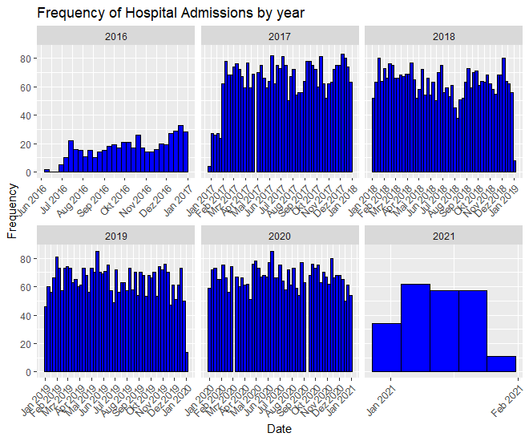

### Flowchart

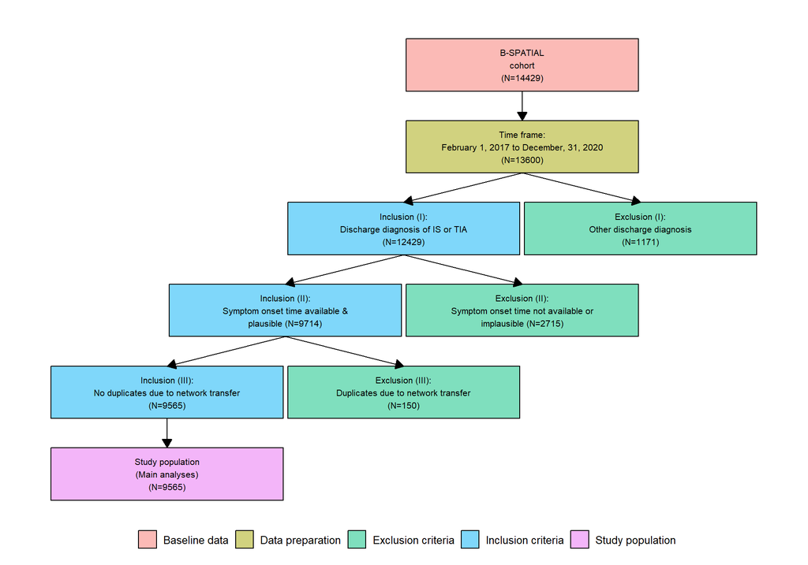

```r
########## prep numbers
dat_raw <- stroke_dat

dat_raw <- dat_raw %>%
  mutate(zip_loc=ifelse(zip_loc<10000,zip_loc+10000,zip_loc)) %>%
  mutate(onset_symp_time2 = as.Date(dat_raw$onset_symp_time))

dat_raw <- dat_raw %>%
  mutate(adm_before = ifelse(dat_raw$adm_time < dat_raw$onset_symp_time2, TRUE, FALSE))

# inclusion
n_cohort <- dat_raw %>%
  nrow()

n_timeframe <- dat_raw %>%
  filter(year(adm_time) < "2021", year(adm_time) > "2016") %>%
  filter(adm_time >= "2017-02-01") %>%
  nrow()

n_inclusion1 <- dat_raw %>%
  filter(year(adm_time) < "2021", year(adm_time) > "2016") %>%
  filter(adm_time >= "2017-02-01") %>%
  filter(icd10=="1" | icd10=="2") %>%
  nrow()


n_inclusion2 <- dat_raw %>%
  filter(year(adm_time) < "2021", year(adm_time) > "2016") %>%
  filter(adm_time >= "2017-02-01") %>%
  filter(icd10=="1" | icd10=="2") %>%
  filter(!is.na(onset_symp_time)) %>%
  filter(adm_before != TRUE)  %>%
  nrow()

n_inclusion3_df <- dat_raw %>%
  filter(year(adm_time) < "2021", year(adm_time) > "2016") %>%
  filter(adm_time >= "2017-02-01") %>%
  filter(icd10=="1" | icd10=="2") %>%
  filter(!is.na(onset_symp_time)) %>%
  filter(adm_before != TRUE)

# identify duplicates
duplicates <- n_inclusion3_df %>%
  mutate(int_transf_numb=ifelse(!is.na(transf_number), transf_number, ifelse(!is.na(displ_numb), displ_numb, NA))) %>% # mutate variable with all transfer numbers
  select(pat_id_exp, adm_time, onset_symp_time, sex, age, transf, int_transf_numb, transf_number, displ_numb, adm_before, onset_symp_time2, everything()) %>%
  filter(int_transf_numb==transf_number | int_transf_numb==displ_numb) %>% # filter by transf_number
  arrange(onset_symp_time, pat_id_exp) %>%
  group_by(int_transf_numb) %>%
  fill(transf_number, displ_numb, living_pre, walk_ability_pre, aht, dm, atr_fibr, prior_event, hlp, chd, pm, le_1, ci, pavk, nic, nic_quant, zip_loc, .direction = "downup") %>%
  filter(!is.na(transf_number) & !is.na(displ_numb))  # there were some single cases inside with only transf_numb or displ_numb but with no other match in other row

exclude_id <- duplicates %>%
  group_by(int_transf_numb) %>%
  slice(-1)

n_inclusion3_clean <- anti_join(n_inclusion3_df, exclude_id, by = "pat_id_exp")

n_inclusion3 <- n_inclusion3_clean %>%
  nrow()

# exclusion
dat_ex1 <- dat_raw %>%
  filter(year(adm_time) < "2021", year(adm_time) > "2016") %>%
  filter(adm_time >= "2017-02-01")
n_exclusion1 <- dat_ex1 %>%
  filter(icd10=="3" | icd10=="4" | icd10=="5") %>%
  nrow()

dat_ex2 <- dat_raw %>%
  filter(year(adm_time) < "2021", year(adm_time) > "2016") %>%
  filter(adm_time >= "2017-02-01") %>%
  filter(icd10=="1" | icd10=="2")
n_exclusion2 <- dat_ex2 %>%
  filter(adm_before == TRUE  | is.na(onset_symp_time)) %>%
  nrow()

dat_ex3 <- dat_raw %>%
  filter(year(adm_time) < "2021", year(adm_time) > "2016") %>%
  filter(adm_time >= "2017-02-01") %>%
  filter(icd10=="1" | icd10=="2") %>%
  filter(adm_before == FALSE  | !is.na(onset_symp_time))

n_exclusion3 <- nrow(dat_ex3) - nrow(n_inclusion3_clean)

########## draw flowcharts

fc_main <- tibble(from = c("B-SPATIAL\ncohort\n(N=)",
                           "B-SPATIAL\ncohort\n(N=)",
                           "B-SPATIAL\ncohort\n(N=)",
                           "Time frame:\nFebruary 1, 2017 to December, 31, 2020\n(N=)",
                           "Time frame:\nFebruary 1, 2017 to December, 31, 2020\n(N=)",
                           "Inclusion (I):\nDischarge diagnosis of IS or TIA\n(N=)",
                           "Inclusion (I):\nDischarge diagnosis of IS or TIA\n(N=)",
                           "Inclusion (II):\nSymptom onset time available &\nplausible (N=)",
                           "Inclusion (II):\nSymptom onset time available &\nplausible (N=)",
                           "Inclusion (III):\nNo duplicates due to network transfer\n(N=)"),
                       to = c("Time frame:\nFebruary 1, 2017 to December, 31, 2020\n(N=)",
                              "Time frame:\nFebruary 1, 2017 to December, 31, 2020\n(N=)",
                              "Time frame:\nFebruary 1, 2017 to December, 31, 2020\n(N=)",
                              "Inclusion (I):\nDischarge diagnosis of IS or TIA\n(N=)",
                              "Exclusion (I):\nOther discharge diagnosis\n(N=)",
                              "Inclusion (II):\nSymptom onset time available &\nplausible (N=)",
                              "Exclusion (II):\nSymptom onset time not available or\nimplausible (N=)",
                              "Inclusion (III):\nNo duplicates due to network transfer\n(N=)",
                              "Exclusion (III):\nDuplicates due to network transfer\n(N=)",
                              "Study population\n(Main analyses)\n(N=)"))

fc_main$from[1] <- gsub("N=", paste0("N=", n_cohort, ""), fc_main$from[1])
fc_main$from[2] <- gsub("N=", paste0("N=", n_cohort, ""), fc_main$from[2])
fc_main$from[3] <- gsub("N=", paste0("N=", n_cohort, ""), fc_main$from[3])
fc_main$from[4] <- gsub("N=", paste0("N=", n_timeframe, ""), fc_main$from[4])
fc_main$from[5] <- gsub("N=", paste0("N=", n_timeframe, ""), fc_main$from[5])
fc_main$from[6] <- gsub("N=", paste0("N=", n_inclusion1, ""), fc_main$from[6])
fc_main$from[7] <- gsub("N=", paste0("N=", n_inclusion1, ""), fc_main$from[7])
fc_main$from[8] <- gsub("N=", paste0("N=", n_inclusion2, ""), fc_main$from[8])
fc_main$from[9] <- gsub("N=", paste0("N=", n_inclusion2, ""), fc_main$from[9])
fc_main$from[10] <- gsub("N=", paste0("N=", n_inclusion3, ""), fc_main$from[10])

fc_main$to[1] <- gsub("N=", paste0("N=", n_timeframe, ""), fc_main$to[1])
fc_main$to[2] <- gsub("N=", paste0("N=", n_timeframe, ""), fc_main$to[2])
fc_main$to[3] <- gsub("N=", paste0("N=", n_timeframe, ""), fc_main$to[3])
fc_main$to[4] <- gsub("N=", paste0("N=", n_inclusion1, ""), fc_main$to[4])
fc_main$to[5] <- gsub("N=", paste0("N=", n_exclusion1, ""), fc_main$to[5])
fc_main$to[6] <- gsub("N=", paste0("N=", n_inclusion2, ""), fc_main$to[6])
fc_main$to[7] <- gsub("N=", paste0("N=", n_exclusion2, ""), fc_main$to[7])
fc_main$to[8] <- gsub("N=", paste0("N=", n_inclusion3, ""), fc_main$to[8])
fc_main$to[9] <- gsub("N=", paste0("N=", n_exclusion3, ""), fc_main$to[9])
fc_main$to[10] <- gsub("N=", paste0("N=",n_inclusion3, ""), fc_main$to[10])


node_data_main <- tibble( name = c("B-SPATIAL\ncohort\n(N=14429)",
                                   "Time frame:\nFebruary 1, 2017 to December, 31, 2020\n(N=13600)",
                                   "Inclusion (I):\nDischarge diagnosis of IS or TIA\n(N=12429)",
                                   "Exclusion (I):\nOther discharge diagnosis\n(N=1171)",
                                   "Inclusion (II):\nSymptom onset time available &\nplausible (N=9714)",
                                   "Exclusion (II):\nSymptom onset time not available or\nimplausible (N=2715)",
                                   "Inclusion (III):\nNo duplicates due to network transfer\n(N=9565)",
                                   "Exclusion (III):\nDuplicates due to network transfer\n(N=150)",
                                   "Study population\n(Main analyses)\n(N=9565)"), type = c("Baseline data",
                                                                                        "Data preparation",
                                                                                        "Inclusion criteria",
                                                                                        "Exclusion criteria",
                                                                                        "Inclusion criteria",
                                                                                        "Exclusion criteria",
                                                                                        "Inclusion criteria",
                                                                                        "Exclusion criteria",
                                                                                        "Study population"))

fc_main_gg <- ggflowchart(fc_main, node_data_main, fill=type, x_nudge = 0.49, y_nudge = 0.32, text_size = 2.75)  #0.42; 0.32

fc_main_gg +
  labs(fill="") +
  theme(legend.position = "bottom", text = element_text(size = 12))
```

### Inclusion & exclusion criteria

- Inclusion: The study population consisted of **patients with the primary discharge diagnosis of ischemic stroke or TIA**.
- Exclusion: **Patients with other discharge diagnoses (e.g., hemorrhagic stroke, stroke mimics), implausible or missing symptom onset times or those identified as transfer patients** were excluded
- A total of 9,565 stroke patients from February 1, 2017, to December 31, 2020, were included in the final analyses. The case-control-ratio was 3.4.

```r
summary_types <- list(
   "Diagnosis at discharge (ICD10)" = list(
    "Ischemic stroke (I63-64)" = ~ n_perc0(dat_pandemic$icd10 == "I63-I64 (ischemic stroke)", na_rm = TRUE, show_denom = "never"),
    "Transisient ischemic attack (G45.0-G45.3/G45.8-G45.9)" = ~ n_perc0(dat_pandemic$icd10 == "G45-0 - G45-3, G45-8 - G45-9 (TIA)", na_rm = TRUE, show_denom = "never"),
    "Missing" = ~ n_perc0(is.na(icd10))))
tblq_types <- summary_table(dat_pandemic, summary_types)
print(tblq_types)
```

|  | dat_pandemic (N = 9,565) |
| --- | --- |
| **Diagnosis at discharge (ICD10)** |  |
| Ischemic stroke (I63-64) | 7,468 (78) |
| Transisient ischemic attack (G45.0-G45.3/G45.8-G45.9) | 2,097 (22) |
| Missing | 0 (0) |

```r
summary_bspatial_miss <- list(
   "Symptom onset time" = list(
    "Available (%)" = ~ n_perc0(!is.na(dat_pandemic$onset_symp_time)),
    "Missing (%)" = ~ n_perc0(is.na(dat_pandemic$onset_symp_time))))
tblq_bspatial_miss <- summary_table(dat_pandemic, summary_bspatial_miss)
print(tblq_bspatial_miss)
```

|  | dat_pandemic (N = 9,565) |
| --- | --- |
| **Symptom onset time** |  |
| Available (%) | 9,565 (100) |
| Missing (%) | 0 (0) |

```r
cases <- sum(dat_analysis_pan_adj$stroke == "1")
controls <- sum(dat_analysis_pan_adj$stroke == "0")
case_control_ratio <- round(controls / cases,2)

summary_cc_ratio <- list(
   "Number of cases and controls" = list(
    "Number of cases" = ~ n_perc0(dat_analysis_pan_adj$stroke == "1", na_rm = TRUE, show_denom = "never"),
    "Number of controls" = ~ n_perc0(dat_analysis_pan_adj$stroke == "0", na_rm = TRUE, show_denom = "never"),
    "Ratio cases:controls" = ~ case_control_ratio,
    "Missing" = ~ n_perc0(is.na(dat_analysis_pan_adj$stroke))))
tblq_cc_ratio <- summary_table(dat_analysis_pan_adj, summary_cc_ratio)
print(tblq_cc_ratio)
```

|  | dat_analysis_pan_adj (N = 42,073) |
| --- | --- |
| **Number of cases and controls** |  |
| Number of cases | 9,565 (23) |
| Number of controls | 32,508 (77) |
| Ratio cases:controls | 3.4 |
| Missing | 0 (0) |

### Table 1

```r
dat_pandemic_tbl1 <- dat_pandemic %>%
  mutate(across(everything(), ~ ifelse(is.na(.), "missing", .)))

dat_pandemic_tbl1$age <- as.numeric(dat_pandemic_tbl1$age)
dat_pandemic_tbl1$nic_quant <- as.numeric(dat_pandemic_tbl1$nic_quant)
dat_pandemic_tbl1$aht <- as.factor(dat_pandemic_tbl1$aht )
dat_pandemic_tbl1$atr_fibr <- as.factor(dat_pandemic_tbl1$atr_fibr )
dat_pandemic_tbl1$dm <- as.factor(dat_pandemic_tbl1$dm )
dat_pandemic_tbl1$hlp <- as.factor(dat_pandemic_tbl1$hlp )
dat_pandemic_tbl1$prior_event <- as.factor(dat_pandemic_tbl1$prior_event )
dat_pandemic_tbl1$chd <- as.factor(dat_pandemic_tbl1$chd )
dat_pandemic_tbl1$pm <- as.factor(dat_pandemic_tbl1$pm )
dat_pandemic_tbl1$pavk <- as.factor(dat_pandemic_tbl1$pavk )
dat_pandemic_tbl1$ci <- as.factor(dat_pandemic_tbl1$ci )
dat_pandemic_tbl1$le_1 <- as.factor(dat_pandemic_tbl1$le_1 )
dat_pandemic_tbl1$nic <- as.factor(dat_pandemic_tbl1$nic )


summary_bspatial1 <- list(
  "Total" = list(~ nrow(dat_pandemic_tbl1)),
  "Age" = list(
    "Min" = ~ min(dat_pandemic_tbl1$age),
    "Median (IQR)" = ~ median_iqr(dat_pandemic_tbl1$age),
    "Mean (SD)" = ~ mean_sd(dat_pandemic_tbl1$age, denote_sd = "paren"),
    "Max" = ~ max(dat_pandemic_tbl1$age),
    "Missing (%)" = ~ n_perc0(is.na(dat_pandemic_tbl1$age))
  ),
  "Sex" = list(
    "Male" = ~ n_perc0(dat_pandemic_tbl1$sex == "3", na_rm = TRUE, show_denom = "never"),
    "Female" = ~ n_perc0(dat_pandemic_tbl1$sex == "2", na_rm = TRUE, show_denom = "never"),
    "Diverse" = ~ n_perc0(dat_pandemic_tbl1$sex == "1", na_rm = TRUE, show_denom = "never"),
    "Missing (%)" = ~ n_perc0(dat_pandemic_tbl1$sex == "missing", na_rm = TRUE, show_denom = "never")
  ),
  "Diagnosis at discharge (ICD10)" = list(
    "Ischemic stroke (I63-64)" = ~ n_perc0(dat_pandemic_tbl1$icd10 == "I63-I64 (ischemic stroke)", na_rm = TRUE, show_denom = "never"),
    "Transisient ischemic attack (G45.0-G45.3/G45.8-G45.9)" = ~ n_perc0(dat_pandemic_tbl1$icd10 == "G45-0 - G45-3, G45-8 - G45-9 (TIA)", na_rm = TRUE, show_denom = "never")
  ),
  "Walk ability before stroke" =
         list("Yes" = ~ n_perc0(dat_pandemic_tbl1$walk_ability_pre == "Yes", na_rm = TRUE, show_denom = "never"),
              "No" = ~ n_perc0(dat_pandemic_tbl1$walk_ability_pre == "No", na_rm = TRUE, show_denom = "never"),
              "Missing (%)" = ~ n_perc0(dat_pandemic_tbl1$walk_ability_pre == "missing", na_rm = TRUE, show_denom = "never")
  ),
  "Living conditions before stroke" =
         list("Alone at home" = ~ n_perc0(dat_pandemic_tbl1$living_pre == "Alone at home", na_rm = TRUE, show_denom = "never"),
              "Together with partner" = ~ n_perc0(dat_pandemic_tbl1$living_pre == "With Partner", na_rm = TRUE, show_denom = "never"),
              "With relatives/acquaintances" = ~ n_perc0(dat_pandemic_tbl1$living_pre == "With Relatives", na_rm = TRUE, show_denom = "never"),
              "Missing (%)" = ~ n_perc0(dat_pandemic_tbl1$living_pre == "missing", na_rm = TRUE, show_denom = "never")
  ),
  "Nicotinconsumption" =
         list("Yes" = ~ n_perc0(dat_pandemic_tbl1$nic == "2", na_rm = TRUE, show_denom = "never"),
              "No" = ~ n_perc0(dat_pandemic_tbl1$nic == "1", na_rm = TRUE, show_denom = "never"),
              "Missing (%)" = ~ n_perc0(dat_pandemic_tbl1$nic == "missing", na_rm = TRUE, show_denom = "never")

  ),
  "Arterial hypertension" =
         list("Yes" = ~ n_perc0(dat_pandemic_tbl1$aht == "2", na_rm = TRUE, show_denom = "never"),
              "No" = ~ n_perc0(dat_pandemic_tbl1$aht == "1", na_rm = TRUE, show_denom = "never"),
               "Missing (%)" = ~ n_perc0(dat_pandemic_tbl1$aht == "missing", na_rm = TRUE, show_denom = "never")
  ),
  "Artrial fibrillation" =
         list("Yes" = ~ n_perc0(dat_pandemic_tbl1$atr_fibr == "2", na_rm = TRUE, show_denom = "never"),
              "No" = ~ n_perc0(dat_pandemic_tbl1$atr_fibr == "1", na_rm = TRUE, show_denom = "never"),
              "Missing (%)" = ~ n_perc0(dat_pandemic_tbl1$atr_fibr == "missing", na_rm = TRUE, show_denom = "never")

  ),
  "Diabetes mellitus" =
         list("Yes" = ~ n_perc0(dat_pandemic_tbl1$dm == "2", na_rm = TRUE, show_denom = "never"),
              "No" = ~ n_perc0(dat_pandemic_tbl1$dm == "1", na_rm = TRUE, show_denom = "never"),
               "Missing (%)" = ~ n_perc0(dat_pandemic_tbl1$dm == "missing", na_rm = TRUE, show_denom = "never")
  ),
  "Prior stroke" =
         list("Yes" = ~ n_perc0(dat_pandemic_tbl1$prior_event == "2", na_rm = TRUE, show_denom = "never"),
              "No" = ~ n_perc0(dat_pandemic_tbl1$prior_event == "1", na_rm = TRUE, show_denom = "never"),
               "Missing (%)" = ~ n_perc0(dat_pandemic_tbl1$prior_event == "missing", na_rm = TRUE, show_denom = "never")
  ),
  "Hyperlipoproteinaemia/ Hypercholesterolaemia" =
         list("Yes" = ~ n_perc0(dat_pandemic_tbl1$hlp == "2", na_rm = TRUE, show_denom = "never"),
              "No" = ~ n_perc0(dat_pandemic_tbl1$hlp == "1", na_rm = TRUE, show_denom = "never"),
                 "Missing (%)" = ~ n_perc0(dat_pandemic_tbl1$hlp == "missing", na_rm = TRUE, show_denom = "never")

  ),
  "Heart Failure" =
         list("Yes" = ~ n_perc0(dat_pandemic_tbl1$ci == "2", na_rm = TRUE, show_denom = "never"),
              "No" = ~ n_perc0(dat_pandemic_tbl1$ci == "1", na_rm = TRUE, show_denom = "never"),
                "Missing (%)" = ~ n_perc0(dat_pandemic_tbl1$ci == "missing", na_rm = TRUE, show_denom = "never")
  ),
  "Coronary Heart Diseases" =
         list("Yes" = ~ n_perc0(dat_pandemic_tbl1$chd == "2", na_rm = TRUE, show_denom = "never"),
              "No" = ~ n_perc0(dat_pandemic_tbl1$chd == "1", na_rm = TRUE, show_denom = "never"),
               "Missing (%)" = ~ n_perc0(dat_pandemic_tbl1$chd == "missing", na_rm = TRUE, show_denom = "never")
  ),
  "Pacemaker" =
         list("Yes" = ~ n_perc0(dat_pandemic_tbl1$pm == "2", na_rm = TRUE, show_denom = "never"),
              "No" = ~ n_perc0(dat_pandemic_tbl1$pm == "1", na_rm = TRUE, show_denom = "never"),
              "Missing (%)" = ~ n_perc0(dat_pandemic_tbl1$pm == "missing", na_rm = TRUE, show_denom = "never")
  ),
 "Peripheral Arterial Occlusive Disease" =
         list("Yes" = ~ n_perc0(dat_pandemic_tbl1$pavk == "2", na_rm = TRUE, show_denom = "never"),
              "No" = ~ n_perc0(dat_pandemic_tbl1$pavk == "1", na_rm = TRUE, show_denom = "never"),
              "Missing (%)" = ~ n_perc0(dat_pandemic_tbl1$pavk == "missing", na_rm = TRUE, show_denom = "never")
  ),
  "Underlying disease with life expectancy < 1 year" =
         list("Yes" = ~ n_perc0(dat_pandemic_tbl1$le_1 == "2", na_rm = TRUE, show_denom = "never"),
              "No" = ~ n_perc0(dat_pandemic_tbl1$le_1 == "1", na_rm = TRUE, show_denom = "never"),
              "Missing (%)" = ~ n_perc0(dat_pandemic_tbl1$le_1 == "missing", na_rm = TRUE, show_denom = "never")
  ))


tblq_bspatial1 <- summary_table(dat_pandemic_tbl1, summary_bspatial1)
print(tblq_bspatial1)
```

|  | dat_pandemic_tbl1 (N = 9,565) |
| --- | --- |
| **Total** |  |
|  | 9565 |
| **Age** |  |
| Min | 18 |
| Median (IQR) | 75.00 (63.00, 81.00) |
| Mean (SD) | 71.51 (13.75) |
| Max | 103 |
| Missing (%) | 0 (0) |
| **Sex** |  |
| Male | 5,224 (55) |
| Female | 4,337 (45) |
| Diverse | 2 (0) |
| Missing (%) | 2 (0) |
| **Diagnosis at discharge (ICD10)** |  |
| Ischemic stroke (I63-64) | 7,468 (78) |
| Transisient ischemic attack (G45.0-G45.3/G45.8-G45.9) | 2,097 (22) |
| **Walk ability before stroke** |  |
| Yes | 9,011 (94) |
| No | 342 (4) |
| Missing (%) | 212 (2) |
| **Living conditions before stroke** |  |
| Alone at home | 2,268 (24) |
| Together with partner | 4,651 (49) |
| With relatives/acquaintances | 383 (4) |
| Missing (%) | 2,263 (24) |
| **Nicotinconsumption** |  |
| Yes | 595 (6) |
| No | 841 (9) |
| Missing (%) | 8,129 (85) |
| **Arterial hypertension** |  |
| Yes | 7,464 (78) |
| No | 2,069 (22) |
| Missing (%) | 32 (0) |
| **Artrial fibrillation** |  |
| Yes | 2,603 (27) |
| No | 6,914 (72) |
| Missing (%) | 48 (1) |
| **Diabetes mellitus** |  |
| Yes | 2,439 (25) |
| No | 7,074 (74) |
| Missing (%) | 52 (1) |
| **Prior stroke** |  |
| Yes | 690 (7) |
| No | 1,850 (19) |
| Missing (%) | 7,025 (73) |
| **Hyperlipoproteinaemia/ Hypercholesterolaemia** |  |
| Yes | 1,495 (16) |
| No | 1,047 (11) |
| Missing (%) | 7,023 (73) |
| **Heart Failure** |  |
| Yes | 312 (3) |
| No | 2,230 (23) |
| Missing (%) | 7,023 (73) |
| **Coronary Heart Diseases** |  |
| Yes | 426 (4) |
| No | 2,110 (22) |
| Missing (%) | 7,029 (73) |
| **Pacemaker** |  |
| Yes | 151 (2) |
| No | 2,387 (25) |
| Missing (%) | 7,027 (73) |
| **Peripheral Arterial Occlusive Disease** |  |
| Yes | 126 (1) |
| No | 2,416 (25) |
| Missing (%) | 7,023 (73) |
| **Underlying disease with life expectancy < 1 year** |  |
| Yes | 88 (1) |
| No | 9,407 (98) |
| Missing (%) | 70 (1) |

```r
tblq_bspatial1_csv <-  as.data.frame(tblq_bspatial1)
```

### Time distribution

```r
holidays <- date(c("2017-01-01", "2017-03-08", "2017-04-14", "2017-04-17", "2017-05-01", "2017-05-25", "2017-06-05", "2017-10-03", "2017-12-25", "2017-12-26","2017-12-31", "2018-01-01", "2018-03-08", "2018-03-30", "2018-04-02", "2018-05-01", "2018-05-10", "2018-05-21", "2018-10-03", "2018-12-25", "2018-12-26", "2018-12-31", "2019-01-01", "2019-03-08", "2019-04-19", "2019-04-22", "2019-05-01", "2019-05-30", "2019-06-10", "2019-10-03", "2019-12-25", "2019-12-26", "2019-12-31", "2020-01-01", "2020-03-08", "2020-04-10", "2020-04-13", "2020-05-01", "2020-05-21", "2020-06-01", "2020-10-03", "2020-12-25", "2020-12-31"))

first_time <- c("0", "1", "2", "3", "4", "5")
second_time <-  c("6", "7", "8", "9", "10", "11")
third_time <-  c("12", "13", "14", "15", "16", "17")
fourth_time <-  c("18", "19", "20", "21", "22", "23")

dat_total <- dat_analysis_pan_adj %>%
  rename(all_time = all_dates)

dat_total <- dat_total %>%
mutate(weekday = weekdays(all_time)) %>%
  mutate(all_date = date(all_time))

#holidays <- as.Date(holidays)
#dat_total$all_date <- as.Date(dat_total$all_date)
#dat_total$holidays <- ifelse(dat_total$all_date %in% holidays, "Yes", "No")

dat_total <- dat_total %>%
#  mutate(time = as_hms(ymd_hms(all_time)))
  mutate(time = hour(all_time))
#dat_total$time <- hour(dat_total$time)

dat_total <- dat_total  %>%
  mutate(time1 = ifelse(time %in% first_time, "Yes", "No")) %>%
  mutate(time2 = ifelse(time %in% second_time, "Yes", "No")) %>%
  mutate(time3 = ifelse(time %in% third_time, "Yes", "No")) %>%
  mutate(time4 = ifelse(time %in% fourth_time, "Yes", "No"))

summary_time_total <- list(
  "Number of strokes by weekday" = list(
    "Mondays (%)" = ~ n_perc0(dat_total$weekday == "Montag", na_rm = TRUE, show_denom = "never"),
    "Tuesdays (%)" = ~ n_perc0(dat_total$weekday == "Dienstag", na_rm = TRUE, show_denom = "never"),
    "Wednesdays (%)" = ~ n_perc0(dat_total$weekday == "Mittwoch", na_rm = TRUE, show_denom = "never"),
    "Thursdays (%)" = ~ n_perc0(dat_total$weekday == "Donnerstag", na_rm = TRUE, show_denom = "never"),
    "Fridays (%)" = ~ n_perc0(dat_total$weekday == "Freitag", na_rm = TRUE, show_denom = "never"),
    "Saturdays (%)" = ~ n_perc0(dat_total$weekday == "Samstag", na_rm = TRUE, show_denom = "never"),
    "Sundays (%)" = ~ n_perc0(dat_total$weekday == "Sonntag", na_rm = TRUE, show_denom = "never"),
    "Missing (%)" = ~ n_perc0(is.na(dat_total$weekday), na_rm = TRUE, show_denom = "never")),
 "Number of strokes by time" = list(
   "00:00-05:59 (%)" = ~ n_perc0(dat_total$time1== "Yes", na_rm = TRUE, show_denom = "never"),
   "06:00-11:59 (%)" = ~ n_perc0(dat_total$time2== "Yes", na_rm = TRUE, show_denom = "never"),
  "12:00-17:59 (%)" = ~ n_perc0(dat_total$time3== "Yes", na_rm = TRUE, show_denom = "never"),
  "18:00-23:59 (%)" = ~ n_perc0(dat_total$time4== "Yes", na_rm = TRUE, show_denom = "never")),
 "Number of strokes at public holiday" = list(
    "Public holiday (%)" = ~ n_perc0(dat_total$holidays == "Yes", na_rm = TRUE, show_denom = "never"),
    "Non public holiday (%)" = ~ n_perc0(dat_total$holidays == "No", na_rm = TRUE, show_denom = "never"))
)


tbl_time_total <- summary_table(dat_total, summary_time_total)

dat_cases <- dat_analysis_pan_adj %>%
  filter(stroke =="1") #%>%

dat_cases <- dat_cases %>%
mutate(weekday = weekdays(case_time)) %>%
  mutate(case_date = date(case_time))

dat_cases <- dat_cases %>%
  mutate(holidays = case_when(adm_time %in% holidays ~ "Yes", TRUE ~ "No")) %>%
  #mutate(time = as_hms(ymd_hms(case_time)))
  mutate(time = hour(case_time))
#dat_cases$time <- hour(dat_cases$time)


dat_cases <- dat_cases  %>%
  mutate(time1 = ifelse(time %in% first_time, "Yes", "No")) %>%
  mutate(time2 = ifelse(time %in% second_time, "Yes", "No")) %>%
  mutate(time3 = ifelse(time %in% third_time, "Yes", "No")) %>%
  mutate(time4 = ifelse(time %in% fourth_time, "Yes", "No"))

summary_time_case <- list(
  "Number of strokes by weekday" = list(
    "Mondays (%)" = ~ n_perc0(dat_cases$weekday == "Montag", na_rm = TRUE, show_denom = "never"),
    "Tuesdays (%)" = ~ n_perc0(dat_cases$weekday == "Dienstag", na_rm = TRUE, show_denom = "never"),
    "Wednesdays (%)" = ~ n_perc0(dat_cases$weekday == "Mittwoch", na_rm = TRUE, show_denom = "never"),
    "Thursdays (%)" = ~ n_perc0(dat_cases$weekday == "Donnerstag", na_rm = TRUE, show_denom = "never"),
    "Fridays (%)" = ~ n_perc0(dat_cases$weekday == "Freitag", na_rm = TRUE, show_denom = "never"),
    "Saturdays (%)" = ~ n_perc0(dat_cases$weekday == "Samstag", na_rm = TRUE, show_denom = "never"),
    "Sundays (%)" = ~ n_perc0(dat_cases$weekday == "Sonntag", na_rm = TRUE, show_denom = "never"),
    "Missing (%)" = ~ n_perc0(is.na(dat_cases$weekday), na_rm = TRUE, show_denom = "never")),
 "Number of strokes by time" = list(
   "00:00-05:59 (%)" = ~ n_perc0(dat_cases$time1== "Yes", na_rm = TRUE, show_denom = "never"),
   "06:00-11:59 (%)" = ~ n_perc0(dat_cases$time2== "Yes", na_rm = TRUE, show_denom = "never"),
  "12:00-17:59 (%)" = ~ n_perc0(dat_cases$time3== "Yes", na_rm = TRUE, show_denom = "never"),
  "18:00-23:59 (%)" = ~ n_perc0(dat_cases$time4== "Yes", na_rm = TRUE, show_denom = "never")),
 "Number of strokes at public holiday" = list(
    "Public holiday (%)" = ~ n_perc0(dat_cases$holidays == "Yes", na_rm = TRUE, show_denom = "never"),
    "Non public holiday (%)" = ~ n_perc0(dat_cases$holidays == "No", na_rm = TRUE, show_denom = "never"))
)


tbl_time_case <- summary_table(dat_cases, summary_time_case)

dat_control <- dat_analysis_pan_adj %>%
  filter(stroke =="0") %>%
  rename(control_time = control_dates)

dat_control <- dat_control %>%
  mutate(weekday = weekdays(control_time)) %>%
  mutate(control_date = date(control_time))

dat_control <- dat_control %>%
#  mutate(time = as_hms(ymd_hms(control_time)))
  mutate(time = hour(control_time))
#dat_control$time <- hour(dat_control$time)

dat_control <- dat_control  %>%
  mutate(time1 = ifelse(time %in% first_time, "Yes", "No")) %>%
  mutate(time2 = ifelse(time %in% second_time, "Yes", "No")) %>%
  mutate(time3 = ifelse(time %in% third_time, "Yes", "No")) %>%
  mutate(time4 = ifelse(time %in% fourth_time, "Yes", "No"))

summary_time_control <- list(
  "Number of strokes by weekday" = list(
    "Mondays (%)" = ~ n_perc0(dat_control$weekday == "Montag", na_rm = TRUE, show_denom = "never"),
    "Tuesdays (%)" = ~ n_perc0(dat_control$weekday == "Dienstag", na_rm = TRUE, show_denom = "never"),
    "Wednesdays (%)" = ~ n_perc0(dat_control$weekday == "Mittwoch", na_rm = TRUE, show_denom = "never"),
    "Thursdays (%)" = ~ n_perc0(dat_control$weekday == "Donnerstag", na_rm = TRUE, show_denom = "never"),
    "Fridays (%)" = ~ n_perc0(dat_control$weekday == "Freitag", na_rm = TRUE, show_denom = "never"),
    "Saturdays (%)" = ~ n_perc0(dat_control$weekday == "Samstag", na_rm = TRUE, show_denom = "never"),
    "Sundays (%)" = ~ n_perc0(dat_control$weekday == "Sonntag", na_rm = TRUE, show_denom = "never"),
    "Missing (%)" = ~ n_perc0(is.na(dat_control$weekday), na_rm = TRUE, show_denom = "never")),
 "Number of strokes by time" = list(
   "00:00-05:59 (%)" = ~ n_perc0(dat_control$time1== "Yes", na_rm = TRUE, show_denom = "never"),
   "06:00-11:59 (%)" = ~ n_perc0(dat_control$time2== "Yes", na_rm = TRUE, show_denom = "never"),
  "12:00-17:59 (%)" = ~ n_perc0(dat_control$time3== "Yes", na_rm = TRUE, show_denom = "never"),
  "18:00-23:59 (%)" = ~ n_perc0(dat_control$time4== "Yes", na_rm = TRUE, show_denom = "never")),
 "Number of strokes at public holiday" = list(
    "Public holiday (%)" = ~ n_perc0(dat_control$holidays == "Yes", na_rm = TRUE, show_denom = "never"),
    "Non public holiday (%)" = ~ n_perc0(dat_control$holidays == "No", na_rm = TRUE, show_denom = "never"))
)



tbl_time_control <- summary_table(dat_control, summary_time_control)



# putting columns together and print final version:
table_time_complete <- cbind(tbl_time_total, tbl_time_case, tbl_time_control)
colnames(table_time_complete) <- c("", "Total", "Cases", "Controls")
print(table_time_complete, rtitle = "Total number of all cases and controls stratified by weekday, daytime and public holiday")
```

|  | dat_total (N = 42,073) | dat_cases (N = 9,565) | dat_control (N = 32,508) |
| --- | --- | --- | --- |
| **Number of strokes by weekday** |  |  |  |
| Mondays (%) | 5,992 (14) | 1,373 (14) | 4,619 (14) |
| Tuesdays (%) | 6,216 (15) | 1,415 (15) | 4,801 (15) |
| Wednesdays (%) | 6,176 (15) | 1,392 (15) | 4,784 (15) |
| Thursdays (%) | 6,440 (15) | 1,466 (15) | 4,974 (15) |
| Fridays (%) | 5,986 (14) | 1,356 (14) | 4,630 (14) |
| Saturdays (%) | 5,552 (13) | 1,262 (13) | 4,290 (13) |
| Sundays (%) | 5,711 (14) | 1,301 (14) | 4,410 (14) |
| Missing (%) | 0 (0) | 0 (0) | 0 (0) |
| **Number of strokes by time** |  |  |  |
| 00:00-05:59 (%) | 1,754 (4) | 404 (4) | 1,350 (4) |
| 06:00-11:59 (%) | 14,862 (35) | 3,382 (35) | 11,480 (35) |
| 12:00-17:59 (%) | 15,988 (38) | 3,637 (38) | 12,351 (38) |
| 18:00-23:59 (%) | 9,469 (23) | 2,142 (22) | 7,327 (23) |
| **Number of strokes at public holiday** |  |  |  |
| Public holiday (%) | 1,337 (3) | 0 (0) | 1,066 (3) |
| Non public holiday (%) | 40,736 (97) | 9,565 (100) | 31,442 (97) |

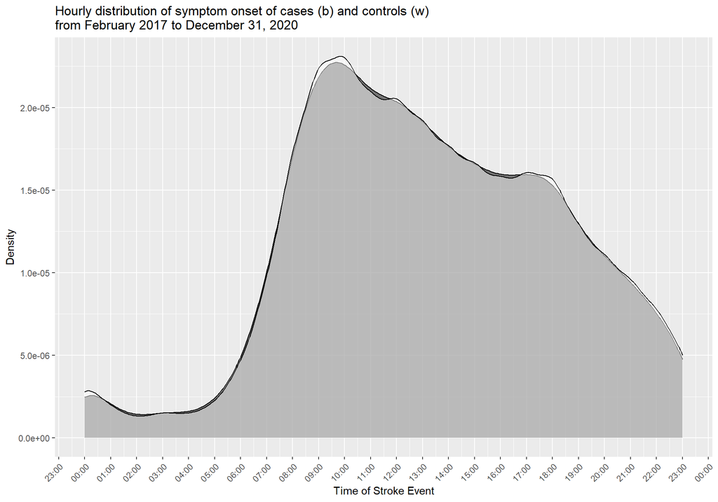

```r
# densplot

dat_hms_cases <- dat_analysis_pan_adj %>%
  filter(stroke == "1")
dat_hms_cases$case_hms <- as_hms(dat_hms_cases$case_time)
dat_hms_cases$case_hms <- as.POSIXct(dat_hms_cases$case_hms)

dat_hms_controls <- dat_analysis_pan_adj %>%
  filter(stroke == "0")
dat_hms_controls$control_hms <- as_hms(dat_hms_controls$control_dates)
dat_hms_controls$control_hms <- as.POSIXct(dat_hms_controls$control_hms)

dens_symp_onset_cases_controls <- ggplot(dat_hms_cases, aes(case_hms)) +
  geom_density(fill = "black", alpha = 0.5) +
  geom_density(data = dat_hms_controls, aes(control_hms), fill = "white", alpha = 0.5) +
  scale_x_datetime(breaks = date_breaks("1 hours"), labels=date_format("%H:%M")) +
  theme(axis.text.x = element_text(angle = 45, hjust = 1)) +
  ggtitle("Hourly distribution of symptom onset of cases (b) and controls (w) \nfrom February 2017 to December 31, 2020") +
  xlab("Time of Stroke Event") +
  ylab("Density")

print(dens_symp_onset_cases_controls)
```

## Exposure data: BLUME network

### PM 2.5 monitoring stations

- Hourly PM2.5 air pollution data were obtained from the **Berlin air quality monitoring network** (BLUME). This network consists of 12 monitoring stations across Berlin, classified into three categories depending on their location at the outer limit of the city, on main streets, or in urban residential areas.
- **Hourly concentrations from the three urban residential stations were combined into a spatial median air pollution concentration on an hourly basis**.
- Although selecting only three of the twelve monitoring stations, **Pearson and Spearman correlation coefficients among all twelve stations and between the three stations are high**.
- According to the definition of the German Federal Environmental Agency the **urban residential stations represent air pollution concentrations typical for the air quality in urban areas**.
- Real-time samples were collected using automatic stray light measurements (Grimm EDM-180 measuring device) and validated retrospectively by laboratory gravimetric reference methods based on 24-hour filter dust, adhering to German law (39th Ordinance on the Implementation of the Federal Immission Control Act (39. BImSchV)) and EU directive (2008/50/EG).
- The BLUME PM2.5 air pollution data are available on the website https://luftdaten.berlin.de/pollution/pm25

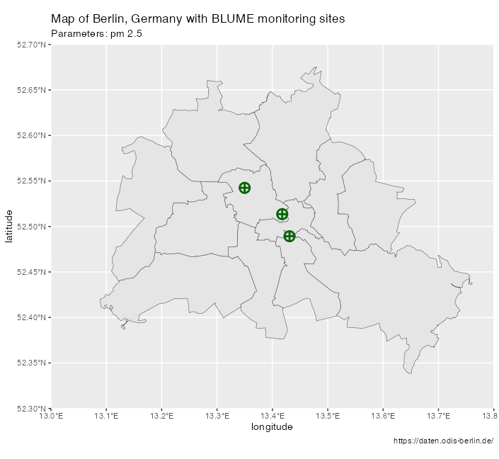

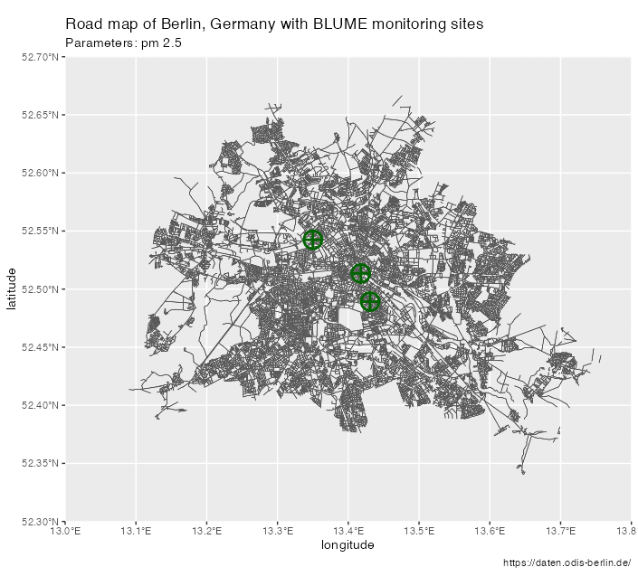

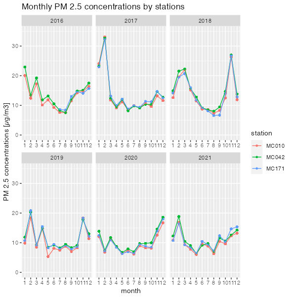

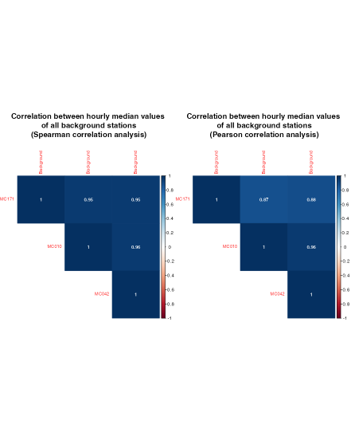

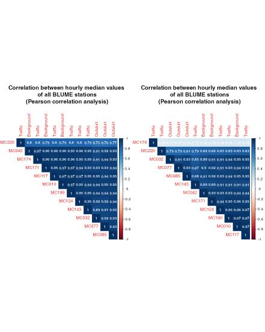

### PM 2.5 values

- **Hourly concentrations from the three urban residential stations were combined into a spatial median air pollution concentration on an hourly basis**, which was then matched to the symptom onset times rounded to the closest full hour. Symptom onset times were rounded to the nearest full hour.

```r
summary_expo_miss <- list(
   "Hourly PM2.5 Median'" = list(
    "Available (%)" = ~ n_perc0(!is.na(dat_analysis_pan_adj$pm25_median_h_Z)),
    "Missing (%)" = ~ n_perc0(is.na(dat_analysis_pan_adj$pm25_median_h_Z))))
tblq_expo_miss <- summary_table(dat_analysis_pan_adj, summary_expo_miss)
print(tblq_expo_miss)
```

|  | dat_analysis_pan_adj (N = 42,073) |
| --- | --- |
| **Hourly PM2.5 Median’** |  |
| Available (%) | 42,073 (100) |
| Missing (%) | 0 (0) |

```r
summary_pm25_med <- list(
 "Hourly PM2.5 Median from February 1, 2017, to December 31, 2020" = list(
    "Min" = ~ min(exposure_pandemic$pm25_median_h),
    "Median (IQR)" = ~ median_iqr(exposure_pandemic$pm25_median_h),
    "Mean (SD)" = ~ mean_sd(exposure_pandemic$pm25_median_h, denote_sd = "paren"),
    "Max" = ~ max(exposure_pandemic$pm25_median_h),
    "Missing (%)" = ~ n_perc0(is.na(pm25_median_h))
  )
)

tblq_pm25_med <- summary_table(exposure_pandemic, summary_pm25_med)
print(tblq_pm25_med)
```

|  | exposure_pandemic (N = 34,320) |
| --- | --- |
| **Hourly PM2.5 Median from February 1, 2017, to December 31, 2020** |  |
| Min | 0.97 |
| Median (IQR) | 10.49 (6.74, 17.56) |
| Mean (SD) | 13.79 (10.28) |
| Max | 185.13 |
| Missing (%) | 0 (0) |

```r
exposure_pandemic_day <- exposure_pandemic

exposure_pandemic_day <- exposure_pandemic_day %>%
  select(case_date, pm25_median_h) %>%
  group_by(case_date) %>%
  mutate(pm25_median_d = median(pm25_median_h)) %>%
  select(case_date, pm25_median_d) %>%
  ungroup() %>%
  distinct()



summary_pm25_med_day <- list(
 "Daily PM2.5 Median from February 1, 2017, to December 31, 2020" = list(
    "Min" = ~ min(exposure_pandemic_day$pm25_median_d),
    "Median (IQR)" = ~ median_iqr(exposure_pandemic_day$pm25_median_d),
    "Mean (SD)" = ~ mean_sd(exposure_pandemic_day$pm25_median_d, denote_sd = "paren"),
    "Max" = ~ max(exposure_pandemic_day$pm25_median_d),
    "Missing (%)" = ~ n_perc0(is.na(pm25_median_d))
  )
)

tblq_pm25_med_day <- summary_table(exposure_pandemic_day, summary_pm25_med_day)
print(tblq_pm25_med_day)
```

|  | exposure_pandemic_day (N = 1,430) |
| --- | --- |
| **Daily PM2.5 Median from February 1, 2017, to December 31, 2020** |  |
| Min | 2.26 |
| Median (IQR) | 10.24 (7.08, 16.37) |
| Mean (SD) | 13.29 (9.28) |
| Max | 64.05 |
| Missing (%) | 0 (0) |

```r
summary_pm25_med_cc <- list(
 "Hourly PM2.5 Median including exposures of cases and controls from February 1, 2017, to December 31, 2020" = list(
    "Min" = ~ min(dat_analysis_pan_adj$pm25_median_h),
    "Median (IQR)" = ~ median_iqr(dat_analysis_pan_adj$pm25_median_h),
    "Mean (SD)" = ~ mean_sd(dat_analysis_pan_adj$pm25_median_h, denote_sd = "paren"),
    "Max" = ~ max(dat_analysis_pan_adj$pm25_median_h),
    "Missing (%)" = ~ n_perc0(is.na(pm25_median_h))
  )
)

tblq_pm25_med_cc <- summary_table(dat_analysis_pan_adj, summary_pm25_med_cc)
print(tblq_pm25_med_cc)
```

|  | dat_analysis_pan_adj (N = 42,073) |
| --- | --- |
| **Hourly PM2.5 Median including exposures of cases and controls from February 1, 2017, to December 31, 2020** |  |
| Min | 0.97 |
| Median (IQR) | 10.03 (6.50, 17.00) |
| Mean (SD) | 13.43 (10.27) |
| Max | 185.13 |
| Missing (%) | 0 (0) |

```r
BLUME <- BLUME_raw_prep
# date & time variables (52.608 rows)
table(is.na(BLUME$date)) #no missings
```

FALSE 34296

```r
table(is.na(BLUME$time)) #no missings
```

FALSE 34296

```r
table(is.na(BLUME$date_time)) #no missings
```

FALSE 34296

```r
# 010 Wedding (BACKGROUND)
table(is.na(BLUME$"MC010")) # 103 missings
```

FALSE TRUE 34193 103

```r
colMeans(is.na(BLUME)) # 0.004
```

```
 date date_time      time      year     month      days     MC010     MC042
```

0.0000000 0.0000000 0.0000000 0.0000000 0.0000000 0.0000000 0.0030033 0.0073186 MC171 0.0026825

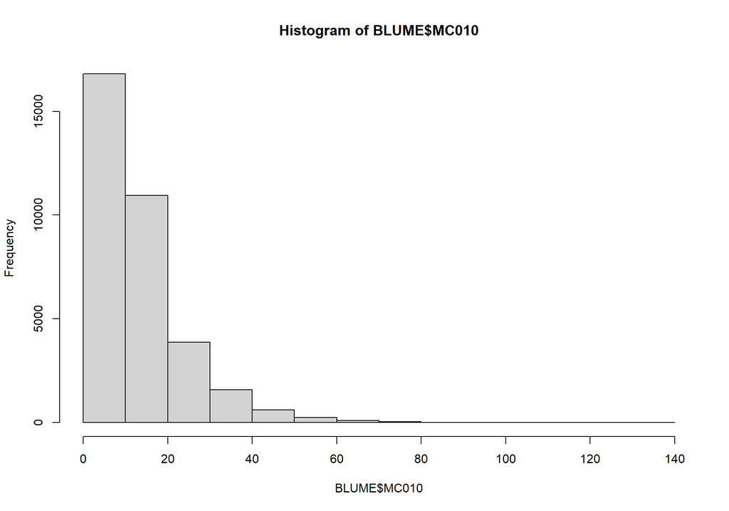

```r
hist(BLUME$"MC010") # distribution skewed right // plausible
```

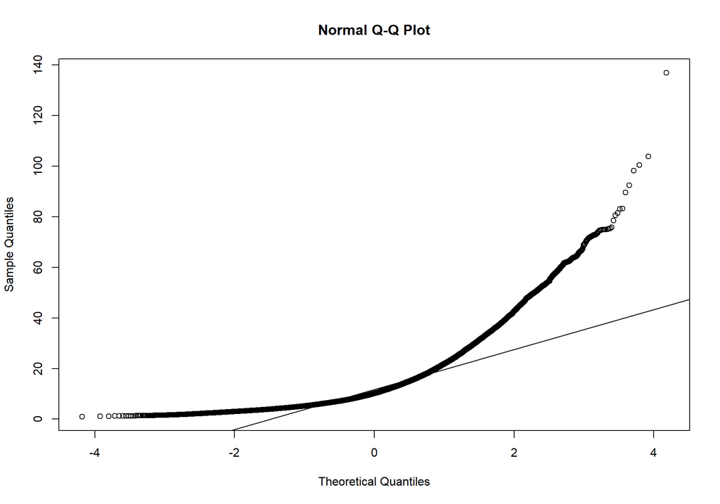

```r
qqnorm(BLUME$"MC010") # normally distributed with outliers (?)
qqline(BLUME$"MC010")
```

```r
median(BLUME$"MC010"[!is.na(BLUME$"MC010")]) # 10.65 µg/m3
```

[1] 10.16

```r
min(BLUME$"MC010"[!is.na(BLUME$"MC010")]) # 0.95 µg/m3
```

[1] 0.95

```r
max(BLUME$"MC010"[!is.na(BLUME$"MC010")]) # 136.99 µg/m3
```

[1] 136.99

```r
quantile(BLUME$"MC010"[!is.na(BLUME$"MC010")], probs = c(0.0, 0.05, 0.25, 0.5, 0.75, 0.95, 1.0))
```

```
 0%      5%     25%     50%     75%     95%    100%
```

0.950 3.610 6.370 10.160 17.030 34.272 136.990

```r
# 042Neukölln (BACKGROUND)
table(is.na(BLUME$"MC042")) # 251 missings
```

FALSE TRUE 34045 251

```r
colMeans(is.na(BLUME)) # 0.009
```

```
 date date_time      time      year     month      days     MC010     MC042
```

0.0000000 0.0000000 0.0000000 0.0000000 0.0000000 0.0000000 0.0030033 0.0073186 MC171 0.0026825

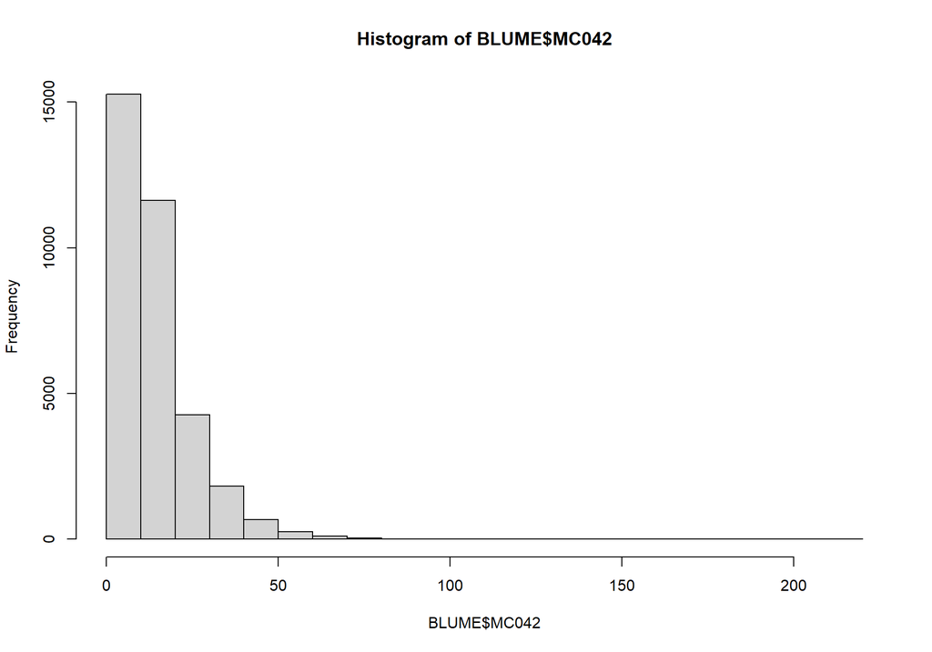

```r
hist(BLUME$"MC042") # distribution skewed right // plausible
```

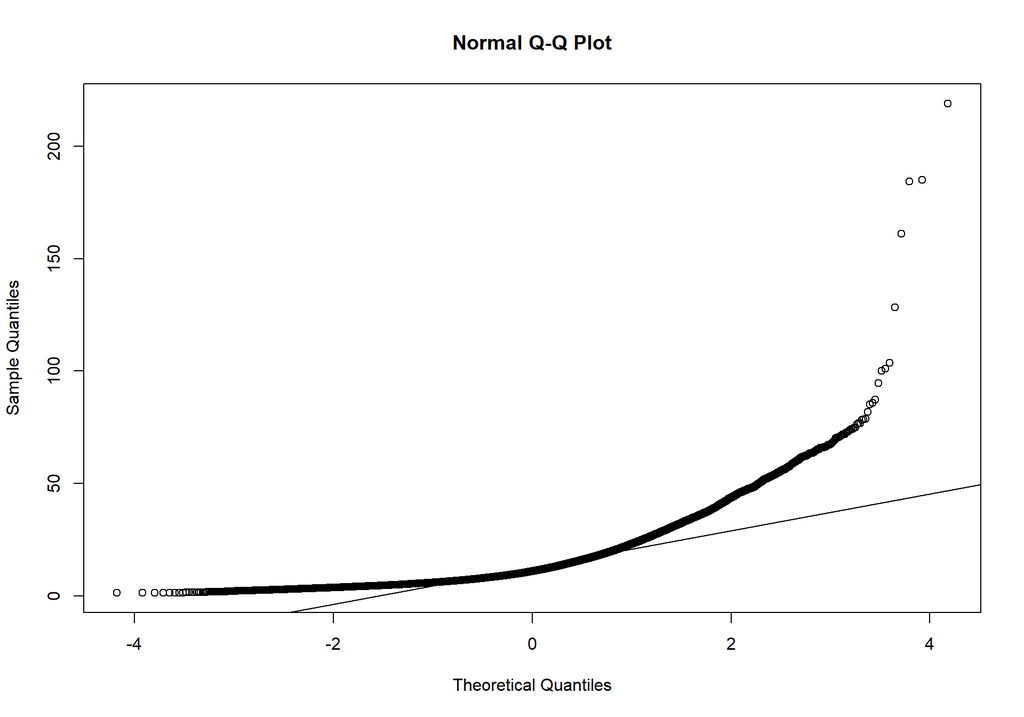

```r
qqnorm(BLUME$"MC042") # normally distributed with outliers (?)
qqline(BLUME$"MC042")
```

```r
median(BLUME$"MC042"[!is.na(BLUME$"MC042")]) # 10.99 µg/m3
```

[1] 10.99

```r
min(BLUME$"MC042"[!is.na(BLUME$"MC042")]) # 1.39 µg/m3
```

[1] 1.39

```r
max(BLUME$"MC042"[!is.na(BLUME$"MC042")]) # 219.07 µg/m3
```

[1] 219.07

```r
quantile(BLUME$"MC042"[!is.na(BLUME$"MC042")], probs = c(0.0, 0.05, 0.25, 0.5, 0.75, 0.95, 1.0))
```

```
0%     5%    25%    50%    75%    95%   100%
```

1.39 4.38 7.12 10.99 18.14 35.19 219.07

```r
# 171 Mitte (BACKGROUND)
table(is.na(BLUME$"MC171")) # 71 missings
```

FALSE TRUE 34204 92

```r
colMeans(is.na(BLUME)) # 0.003
```

```
 date date_time      time      year     month      days     MC010     MC042
```

0.0000000 0.0000000 0.0000000 0.0000000 0.0000000 0.0000000 0.0030033 0.0073186 MC171 0.0026825

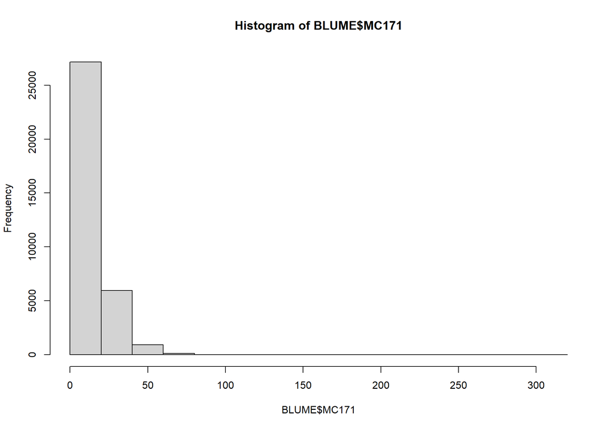

```r
hist(BLUME$"MC171") # distribution skewed right // plausible
```

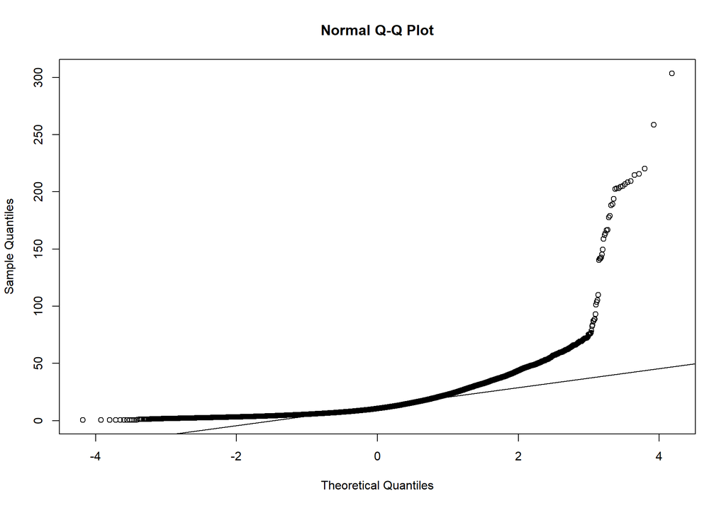

```r
qqnorm(BLUME$"MC171") # normally distributed with outliers (?)
qqline(BLUME$"MC171")
```

```r
median(BLUME$"MC171"[!is.na(BLUME$"MC171")]) # 11.2 µg/m3
```

[1] 10.6

```r
min(BLUME$"MC171"[!is.na(BLUME$"MC171")]) # 0.6 µg/m3
```

[1] 0.6

```r
max(BLUME$"MC171"[!is.na(BLUME$"MC171")]) # 303.67 µg/m3
```

[1] 303.67

```r
quantile(BLUME$"MC171"[!is.na(BLUME$"MC171")], probs = c(0.0, 0.05, 0.25, 0.5, 0.75, 0.95, 1.0))
```

```
  0%       5%      25%      50%      75%      95%     100%
```

0.6000 3.9200 6.7375 10.6000 17.9100 35.4985 303.6700

### PM 2.5 distribution

- Average PM 2.5 values differed when stratifying by weekday, daytime, public holiday or year.
- The PM 2.5 values were **right-skewed**. The **QQ-plot confirms the right-skewness** and indicates a **rather non-normal distribution**.

```r
holidays <- date(c("2017-01-01", "2017-03-08", "2017-04-14", "2017-04-17", "2017-05-01", "2017-05-25", "2017-06-05", "2017-10-03", "2017-12-25", "2017-12-26","2017-12-31", "2018-01-01", "2018-03-08", "2018-03-30", "2018-04-02", "2018-05-01", "2018-05-10", "2018-05-21", "2018-10-03", "2018-12-25", "2018-12-26", "2018-12-31", "2019-01-01", "2019-03-08", "2019-04-19", "2019-04-22", "2019-05-01", "2019-05-30", "2019-06-10", "2019-10-03", "2019-12-25", "2019-12-26", "2019-12-31", "2020-01-01", "2020-03-08", "2020-04-10", "2020-04-13", "2020-05-01", "2020-05-21", "2020-06-01", "2020-10-03", "2020-12-25", "2020-12-31"))

first_time <- c("0", "1", "2", "3", "4", "5")
second_time <-  c("6", "7", "8", "9", "10", "11")
third_time <-  c("12", "13", "14", "15", "16", "17")
fourth_time <-  c("18", "19", "20", "21", "22", "23")

dat_total <- dat_analysis_pan_adj %>%
  rename(all_time = all_dates)

dat_total <- dat_total %>%
mutate(weekday = weekdays(all_time)) %>%
  mutate(all_date = date(all_time))

#holidays <- as.Date(holidays)
#dat_total$all_date <- as.Date(dat_total$all_date)
#dat_total$holidays <- ifelse(dat_total$all_date %in% holidays, "Yes", "No")

dat_total <- dat_total %>%
  #mutate(time = as_hms(ymd_hms(all_time)))
  mutate(time = hour(all_time))
#dat_total$time <- hour(dat_total$time)

dat_total <- dat_total  %>%
  mutate(time1 = ifelse(time %in% first_time, "Yes", "No")) %>%
  mutate(time2 = ifelse(time %in% second_time, "Yes", "No")) %>%
  mutate(time3 = ifelse(time %in% third_time, "Yes", "No")) %>%
  mutate(time4 = ifelse(time %in% fourth_time, "Yes", "No"))



summary_time_pm25_total <- list(
  "Median PM 2.5 concentrations [µg/m3] by weekday" = list(
    "Mondays" = ~ median(dat_total$pm25_median_h[dat_total$weekday == "Montag"], na_rm = TRUE, show_denom = "never"),
    "Tuesdays" = ~ median(dat_total$pm25_median_h[dat_total$weekday == "Dienstag"], na_rm = TRUE, show_denom = "never"),
    "Wednesdays" = ~ median(dat_total$pm25_median_h[dat_total$weekday == "Mittwoch"], na_rm = TRUE, show_denom = "never"),
    "Thursdays" = ~ median(dat_total$pm25_median_h[dat_total$weekday == "Donnerstag"], na_rm = TRUE, show_denom = "never"),
    "Fridays" = ~ median(dat_total$pm25_median_h[dat_total$weekday == "Freitag"], na_rm = TRUE, show_denom = "never"),
    "Saturdays" = ~ median(dat_total$pm25_median_h[dat_total$weekday == "Samstag"], na_rm = TRUE, show_denom = "never"),
    "Sundays" = ~ median(dat_total$pm25_median_h[dat_total$weekday == "Sonntag"], na_rm = TRUE, show_denom = "never")),
 "Median PM 2.5 concentrations [µg/m3] by time" = list(
   "00:00-05:59" = ~  median(dat_total$pm25_median_h[dat_total$time1== "Yes"], na_rm = TRUE, show_denom = "never"),
   "06:00-11:59" = ~ median(dat_total$pm25_median_h[dat_total$time2== "Yes"], show_denom = "never"),
  "12:00-17:59" = ~ median(dat_total$pm25_median_h[dat_total$time3== "Yes"], na_rm = TRUE, show_denom = "never"),
  "18:00-23:59" = ~ median(dat_total$pm25_median_h[dat_total$time4== "Yes"], na_rm = TRUE, show_denom = "never")),
 "Median PM 2.5 concentrations [µg/m3] at public holiday" = list(
    "Public holiday" = ~ median(dat_total$pm25_median_h[dat_total$holidays == "Yes"], na_rm = TRUE, show_denom = "never"),
    "Non public holiday" = ~ median(dat_total$pm25_median_h[dat_total$holidays == "No"], na_rm = TRUE, show_denom = "never"))
)

tbl_time_pm25_total <- summary_table(dat_total, summary_time_pm25_total)



dat_cases <- dat_analysis_pan_adj %>%
  filter(stroke =="1") #%>%

dat_cases <- dat_cases %>%
mutate(weekday = weekdays(case_time)) %>%
  mutate(case_date = date(case_time))

dat_cases <- dat_cases %>%
  mutate(holiday = case_when(adm_time %in% holidays ~ "Yes", TRUE ~ "No")) %>%
 # mutate(time = as_hms(ymd_hms(case_time)))
  mutate(time = hour(case_time))
#dat_cases$time <- hour(dat_cases$time)

dat_cases <- dat_cases  %>%
  mutate(time1 = ifelse(time %in% first_time, "Yes", "No")) %>%
  mutate(time2 = ifelse(time %in% second_time, "Yes", "No")) %>%
  mutate(time3 = ifelse(time %in% third_time, "Yes", "No")) %>%
  mutate(time4 = ifelse(time %in% fourth_time, "Yes", "No"))



summary_time_pm25_case <- list(
  "Median PM 2.5 concentrations [µg/m3] by weekday" = list(
    "Mondays" = ~ median(dat_cases$pm25_median_h[dat_cases$weekday == "Montag"], na_rm = TRUE, show_denom = "never"),
    "Tuesdays" = ~ median(dat_cases$pm25_median_h[dat_cases$weekday == "Dienstag"], na_rm = TRUE, show_denom = "never"),
    "Wednesdays" = ~ median(dat_cases$pm25_median_h[dat_cases$weekday == "Mittwoch"], na_rm = TRUE, show_denom = "never"),
    "Thursdays" = ~ median(dat_cases$pm25_median_h[dat_cases$weekday == "Donnerstag"], na_rm = TRUE, show_denom = "never"),
    "Fridays" = ~ median(dat_cases$pm25_median_h[dat_cases$weekday == "Freitag"], na_rm = TRUE, show_denom = "never"),
    "Saturdays" = ~ median(dat_cases$pm25_median_h[dat_cases$weekday == "Samstag"], na_rm = TRUE, show_denom = "never"),
    "Sundays" = ~ median(dat_cases$pm25_median_h[dat_cases$weekday == "Sonntag"], na_rm = TRUE, show_denom = "never")),
 "Median PM 2.5 concentrations [µg/m3] by time" = list(
   "00:00-05:59" = ~  median(dat_cases$pm25_median_h[dat_cases$time1== "Yes"], na_rm = TRUE, show_denom = "never"),
   "06:00-11:59" = ~ median(dat_cases$pm25_median_h[dat_cases$time2== "Yes"], show_denom = "never"),
  "12:00-17:59" = ~ median(dat_cases$pm25_median_h[dat_cases$time3== "Yes"], na_rm = TRUE, show_denom = "never"),
  "18:00-23:59" = ~ median(dat_cases$pm25_median_h[dat_cases$time4== "Yes"], na_rm = TRUE, show_denom = "never")),
 "Median PM 2.5 concentrations [µg/m3] at public holiday" = list(
    "Public holiday" = ~ median(dat_cases$pm25_median_h[dat_cases$holidays == "Yes"], na_rm = TRUE, show_denom = "never"),
    "Non public holiday" = ~ median(dat_cases$pm25_median_h[dat_cases$holidays == "No"], na_rm = TRUE, show_denom = "never"))
)

tbl_time_pm25_case <- summary_table(dat_cases, summary_time_pm25_case)

dat_control <- dat_analysis_pan_adj %>%
  filter(stroke =="0") %>%
  rename(control_time = control_dates)

dat_control <- dat_control %>%
  mutate(weekday = weekdays(control_time)) %>%
  mutate(control_date = date(control_time))

dat_control <- dat_control %>%
  #mutate(time = as_hms(ymd_hms(control_time)))
  mutate(time = hour(control_time))
#dat_control$time <- hour(dat_control$time)

dat_control <- dat_control  %>%
  mutate(time1 = ifelse(time %in% first_time, "Yes", "No")) %>%
  mutate(time2 = ifelse(time %in% second_time, "Yes", "No")) %>%
  mutate(time3 = ifelse(time %in% third_time, "Yes", "No")) %>%
  mutate(time4 = ifelse(time %in% fourth_time, "Yes", "No"))



summary_time_pm25_control <- list(
  "Median PM 2.5 concentrations [µg/m3] by weekday" = list(
    "Mondays" = ~ median(dat_control$pm25_median_h[dat_control$weekday == "Montag"], na_rm = TRUE, show_denom = "never"),
    "Tuesdays" = ~ median(dat_control$pm25_median_h[dat_control$weekday == "Dienstag"], na_rm = TRUE, show_denom = "never"),
    "Wednesdays" = ~ median(dat_control$pm25_median_h[dat_control$weekday == "Mittwoch"], na_rm = TRUE, show_denom = "never"),
    "Thursdays" = ~ median(dat_control$pm25_median_h[dat_control$weekday == "Donnerstag"], na_rm = TRUE, show_denom = "never"),
    "Fridays" = ~ median(dat_control$pm25_median_h[dat_control$weekday == "Freitag"], na_rm = TRUE, show_denom = "never"),
    "Saturdays" = ~ median(dat_control$pm25_median_h[dat_control$weekday == "Samstag"], na_rm = TRUE, show_denom = "never"),
    "Sundays" = ~ median(dat_control$pm25_median_h[dat_control$weekday == "Sonntag"], na_rm = TRUE, show_denom = "never")),
 "Median PM 2.5 concentrations [µg/m3] by time" = list(
   "00:00-05:59" = ~  median(dat_control$pm25_median_h[dat_control$time1== "Yes"], na_rm = TRUE, show_denom = "never"),
   "06:00-11:59" = ~ median(dat_control$pm25_median_h[dat_control$time2== "Yes"], show_denom = "never"),
  "12:00-17:59" = ~ median(dat_control$pm25_median_h[dat_control$time3== "Yes"], na_rm = TRUE, show_denom = "never"),
  "18:00-23:59" = ~ median(dat_control$pm25_median_h[dat_control$time4== "Yes"], na_rm = TRUE, show_denom = "never")),
 "Median PM 2.5 concentrations [µg/m3] at public holiday" = list(
    "Public holiday" = ~ median(dat_control$pm25_median_h[dat_control$holidays == "Yes"], na_rm = TRUE, show_denom = "never"),
    "Non public holiday" = ~ median(dat_control$pm25_median_h[dat_control$holidays == "No"], na_rm = TRUE, show_denom = "never"))
)

tbl_time_pm25_control <- summary_table(dat_control, summary_time_pm25_control)


# putting columns together and print final version:

table_time_pm25_complete <- cbind(tbl_time_pm25_total, tbl_time_pm25_case, tbl_time_pm25_control)
colnames(table_time_pm25_complete) <- c(" ", "Total", "Cases", "Controls")
print(table_time_pm25_complete, rtitle = "Median PM2.5 concentration of all cases and controls stratified by weekday, daytime and public holiday")
```

|  | dat_total (N = 42,073) | dat_cases (N = 9,565) | dat_control (N = 32,508) |
| --- | --- | --- | --- |
| **Median PM 2.5 concentrations [µg/m3] by weekday** |  |  |  |
| Mondays | 9.25 | 9.255 | 9.25 |
| Tuesdays | 9.63 | 9.62 | 9.65 |
| Wednesdays | 10.43 | 10.66 | 10.345 |
| Thursdays | 10.905 | 11.24 | 10.77 |
| Fridays | 11.28 | 11.375 | 11.26 |
| Saturdays | 10.175 | 9.815 | 10.31 |
| Sundays | 9.12 | 9.29 | 9.04 |
| **Median PM 2.5 concentrations [µg/m3] by time** |  |  |  |
| 00:00-05:59 | 11.575 | 11.395 | 11.6 |
| 06:00-11:59 | 11.695 | 11.865 | 11.635 |
| 12:00-17:59 | 8.69 | 8.84 | 8.67 |
| 18:00-23:59 | 9.85 | 9.885 | 9.84 |
| **Median PM 2.5 concentrations [µg/m3] at public holiday** |  |  |  |
| Public holiday | 9.02 | 9.45 | 8.92 |
| Non public holiday | 10.05 | 10.17 | 10.02 |

```r
dat_sep <- dat_analysis_pan_adj %>%
  rename(all_time = all_dates)

dat_sep <- dat_sep %>%
mutate(weekday = weekdays(all_time)) %>%
  mutate(all_date = date(all_time))

dat_sep <- dat_sep %>%
#  mutate(time = as_hms(ymd_hms(all_time)))
  mutate(time = hour(all_time))
#dat_sep$time <- hour(dat_sep$time)

summary_sep_pm25_total <- list(
  "Hourly PM 2.5 concentrations [µg/m3]" = list(
    "IQR" = ~ IQR(dat_sep$pm25_median_h),
    "Min" = ~ min(dat_sep$pm25_median_h, na_rm = TRUE, show_denom = "never"),
    "Q1" = ~ quantile(dat_sep$pm25_median_h, probs = c(0.25)),
    "Median" = ~ median(dat_sep$pm25_median_h, na_rm = TRUE, show_denom = "never"),
    "Q3" = ~ quantile(dat_sep$pm25_median_h, probs = c(0.75)),
    "Max" = ~ max(dat_sep$pm25_median_h)))

tbl_sep_pm25_total <- summary_table(dat_sep, summary_sep_pm25_total)

dat_sep_case <- dat_analysis_pan_adj %>%
  rename(all_time = all_dates) %>%
  filter(stroke == "1")

dat_sep_case <- dat_sep_case %>%
mutate(weekday = weekdays(all_time)) %>%
  mutate(all_date = date(all_time))

dat_sep_case <- dat_sep_case %>%
  #mutate(time = as_hms(ymd_hms(all_time)))
  mutate(time = hour(all_time))
#dat_sep_case$time <- hour(dat_sep_case$time)

summary_sep_case_pm25_total <- list(
  "Hourly PM 2.5 concentrations [µg/m3]" = list(
    "IQR" = ~ IQR(dat_sep_case$pm25_median_h),
    "Min" = ~ min(dat_sep_case$pm25_median_h, na_rm = TRUE, show_denom = "never"),
    "Q1" = ~ quantile(dat_sep_case$pm25_median_h, probs = c(0.25)),
    "Median" = ~ median(dat_sep_case$pm25_median_h, na_rm = TRUE, show_denom = "never"),
    "Q3" = ~ quantile(dat_sep_case$pm25_median_h, probs = c(0.75)),
    "Max" = ~ max(dat_sep_case$pm25_median_h)))

tbl_sep_case_pm25_total <- summary_table(dat_sep_case, summary_sep_case_pm25_total)

dat_sep_control <- dat_analysis_pan_adj %>%
  rename(all_time = all_dates) %>%
  filter(stroke == "0")

dat_sep_control <- dat_sep_control %>%
mutate(weekday = weekdays(all_time)) %>%
  mutate(all_date = date(all_time))

dat_sep_control <- dat_sep_control %>%
  #mutate(time = as_hms(ymd_hms(all_time)))
  mutate(time = hour(all_time))
#dat_sep_control$time <- hour(dat_sep_control$time)

summary_sep_control_pm25_total <- list(
  "Hourly PM 2.5 concentrations [µg/m3]" = list(
    "IQR" = ~ IQR(dat_sep_control$pm25_median_h),
    "Min" = ~ min(dat_sep_control$pm25_median_h, na_rm = TRUE, show_denom = "never"),
    "Q1" = ~ quantile(dat_sep_control$pm25_median_h, probs = c(0.25)),
    "Median" = ~ median(dat_sep_control$pm25_median_h, na_rm = TRUE, show_denom = "never"),
    "Q3" = ~ quantile(dat_sep_control$pm25_median_h, probs = c(0.75)),
    "Max" = ~ max(dat_sep_control$pm25_median_h)))

tbl_sep_control_pm25_total <- summary_table(dat_sep_control, summary_sep_control_pm25_total)



# putting columns together and print final version:

table_sep_pm25_complete <- cbind(tbl_sep_pm25_total, tbl_sep_case_pm25_total, tbl_sep_control_pm25_total)
colnames(table_sep_pm25_complete) <- c(" ","Total", "Cases", "Controls")
print(table_sep_pm25_complete, rtitle = "Median PM2.5 concentration of all cases and controls")
```

|  | dat_sep (N = 42,073) | dat_sep_case (N = 9,565) | dat_sep_control (N = 32,508) |
| --- | --- | --- | --- |
| **Hourly PM 2.5 concentrations [µg/m3]** |  |  |  |
| IQR | 10.5 | 10.68 | 10.44 |
| Min | 0.97 | 1 | 0.97 |
| Q1 | 6.5 | 6.54 | 6.48 |
| Median | 10.03 | 10.16 | 10.01 |
| Q3 | 17 | 17.22 | 16.92 |
| Max | 185.13 | 185.13 | 136.99 |

```r
summary_tbl_total_pm25 <- list(
  "Hourly PM2.5 Median" = list(
    "Min" = ~ min(exposure_pandemic$pm25_median_h, na.rm=TRUE),
    "Median (IQR)" = ~ median_iqr(exposure_pandemic$pm25_median_h, na_rm=TRUE),
    "Mean (SD)" = ~ mean_sd(exposure_pandemic$pm25_median_h, denote_sd = "paren",, na_rm=TRUE),
    "Max" = ~ max(exposure_pandemic$pm25_median_h, na.rm=TRUE),
    "Missing (%)" = ~ n_perc0(is.na(exposure_pandemic$pm25_median_h))))

tbl_compl_dat <- summary_table(exposure_pandemic, summary_tbl_total_pm25)


#2017
dat_2017_pm25 <- exposure_pandemic %>%
  filter(year(case_date)=="2017")

summary_tbl_2017_pm25 <- list(
  "Hourly PM2.5 Median" = list(
    "Min" = ~ min(dat_2017_pm25$pm25_median_h),
    "Median (IQR)" = ~ median_iqr(dat_2017_pm25$pm25_median_h),
    "Mean (SD)" = ~ mean_sd(dat_2017_pm25$pm25_median_h, denote_sd = "paren"),
    "Max" = ~ max(dat_2017_pm25$pm25_median_h),
    "Missing (%)" = ~ n_perc0(is.na(dat_2017_pm25$pm25_median_h))))
tbl_2017_pm25 <- summary_table(dat_2017_pm25, summary_tbl_2017_pm25)



#2018
dat_2018_pm25 <- exposure_pandemic %>%
  filter(year(case_date)=="2018")

summary_tbl_2018_pm25 <- list(
  "Hourly PM2.5 Median" = list(
    "Min" = ~ min(dat_2018_pm25$pm25_median_h),
    "Median (IQR)" = ~ median_iqr(dat_2018_pm25$pm25_median_h),
    "Mean (SD)" = ~ mean_sd(dat_2018_pm25$pm25_median_h, denote_sd = "paren"),
    "Max" = ~ max(dat_2018_pm25$pm25_median_h),
    "Missing (%)" = ~ n_perc0(is.na(dat_2018_pm25$pm25_median_h))))
tbl_2018_pm25 <- summary_table(dat_2018_pm25, summary_tbl_2018_pm25)


#2019
dat_2019_pm25 <- exposure_pandemic %>%
  filter(year(case_date)=="2019")

summary_tbl_2019_pm25 <- list(
  "Hourly PM2.5 Median" = list(
    "Min" = ~ min(dat_2019_pm25$pm25_median_h),
    "Median (IQR)" = ~ median_iqr(dat_2019_pm25$pm25_median_h),
    "Mean (SD)" = ~ mean_sd(dat_2019_pm25$pm25_median_h, denote_sd = "paren"),
    "Max" = ~ max(dat_2019_pm25$pm25_median_h),
    "Missing (%)" = ~ n_perc0(is.na(dat_2019_pm25$pm25_median_h))))
tbl_2019_pm25 <- summary_table(dat_2019_pm25, summary_tbl_2019_pm25)


#2020
dat_2020_pm25 <- exposure_pandemic %>%
  filter(year(case_date)=="2020")

summary_tbl_2020_pm25 <- list(
  "Hourly PM2.5 Median" = list(
    "Min" = ~ min(dat_2020_pm25$pm25_median_h),
    "Median (IQR)" = ~ median_iqr(dat_2020_pm25$pm25_median_h),
    "Mean (SD)" = ~ mean_sd(dat_2020_pm25$pm25_median_h, denote_sd = "paren"),
    "Max" = ~ max(dat_2020_pm25$pm25_median_h),
    "Missing (%)" = ~ n_perc0(is.na(dat_2020_pm25$pm25_median_h))))
tbl_2020_pm25 <- summary_table(dat_2020_pm25, summary_tbl_2020_pm25)


# merge tables
tbl_compl_pm25 <- cbind(tbl_compl_dat, tbl_2017_pm25, tbl_2018_pm25, tbl_2019_pm25, tbl_2020_pm25)
colnames(tbl_compl_pm25) <- c("", "Total","2017", "2018","2019","2020")

print(tbl_compl_pm25, rtitle = "Median hourly concentration of PM2.5 stratified by years")
```

```
##
##
## |                          |exposure_pandemic (N = 34,320) |dat_2017_pm25 (N = 8,016) |dat_2018_pm25 (N = 8,760) |dat_2019_pm25 (N = 8,760) |dat_2020_pm25 (N = 8,784) |
## |:-------------------------|:------------------------------|:-------------------------|:-------------------------|:-------------------------|:-------------------------|
## |**Hourly PM2.5 Median**   |&nbsp;&nbsp;                   |&nbsp;&nbsp;              |&nbsp;&nbsp;              |&nbsp;&nbsp;              |&nbsp;&nbsp;              |
## |&nbsp;&nbsp; Min          |0.97                           |1.4                       |1.29                      |0.97                      |1.62                      |
## |&nbsp;&nbsp; Median (IQR) |10.49 (6.74, 17.56)            |10.95 (7.25, 17.80)       |12.56 (7.45, 21.89)       |10.10 (6.62, 17.05)       |8.95 (5.97, 14.75)        |
## |&nbsp;&nbsp; Mean (SD)    |13.79 (10.28)                  |14.33 (10.58)             |16.18 (11.76)             |13.38 (10.07)             |11.30 (7.71)              |
## |&nbsp;&nbsp; Max          |185.13                         |74.29                     |136.99                    |185.13                    |184.22                    |
## |&nbsp;&nbsp; Missing (%)  |0 (0)                          |0 (0)                     |0 (0)                     |0 (0)                     |0 (0)                     |
```

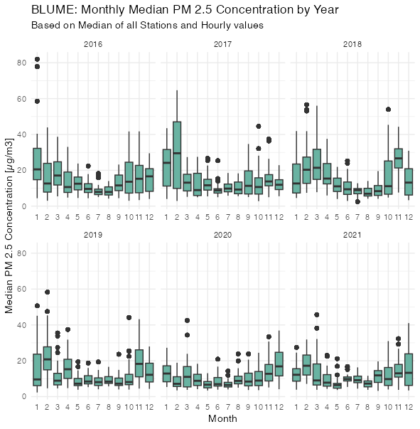

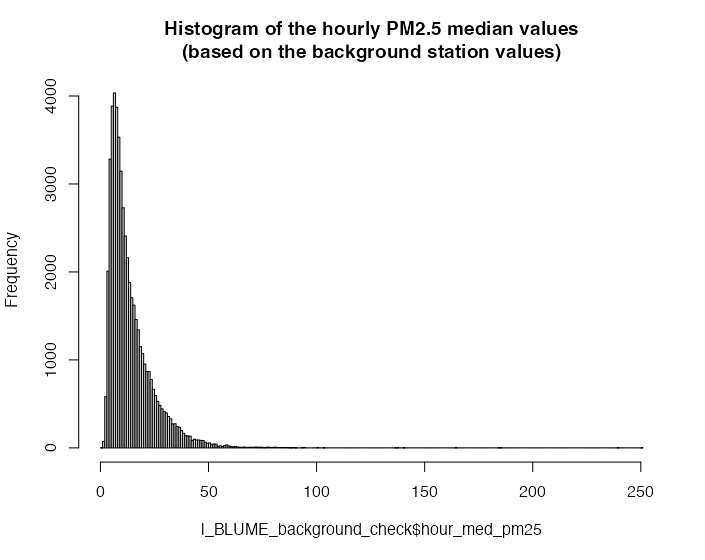

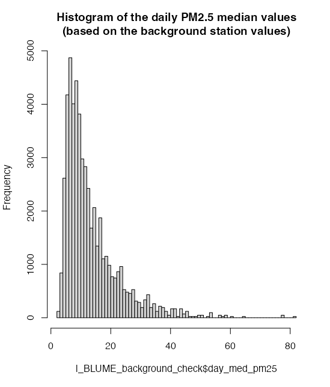

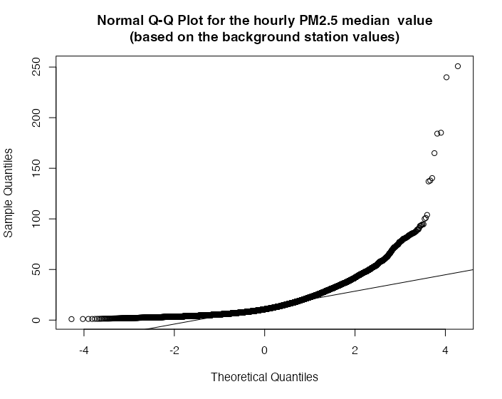

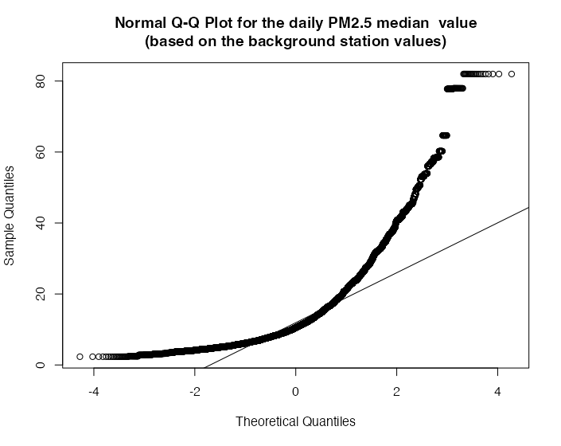

### ACF for PM2.5 exposure

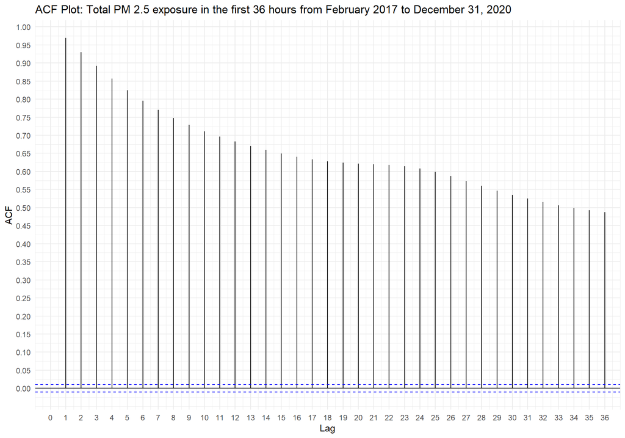

```r
# calculate acf

##### 36 hours
# acf for total exposure
acf_BLUME_36h_total <- ggAcf(exposure_pandemic$pm25_median_h_Z, lag.max = 36) +
  scale_x_continuous(breaks = seq(0, 36, by = 1),limits = c(0, 36), expand = c(0,1)) +
  scale_y_continuous(breaks = seq(0, 1, by = 0.05)) +
  labs(title = "ACF Plot: Total PM 2.5 exposure in the first 36 hours from February 2017 to December 31, 2020") +
  theme_minimal()
# result: data shows very strong positive correlation (> 0.5-1.0) and a decreasing wave in the first 36 hours.
print(acf_BLUME_36h_total)
```

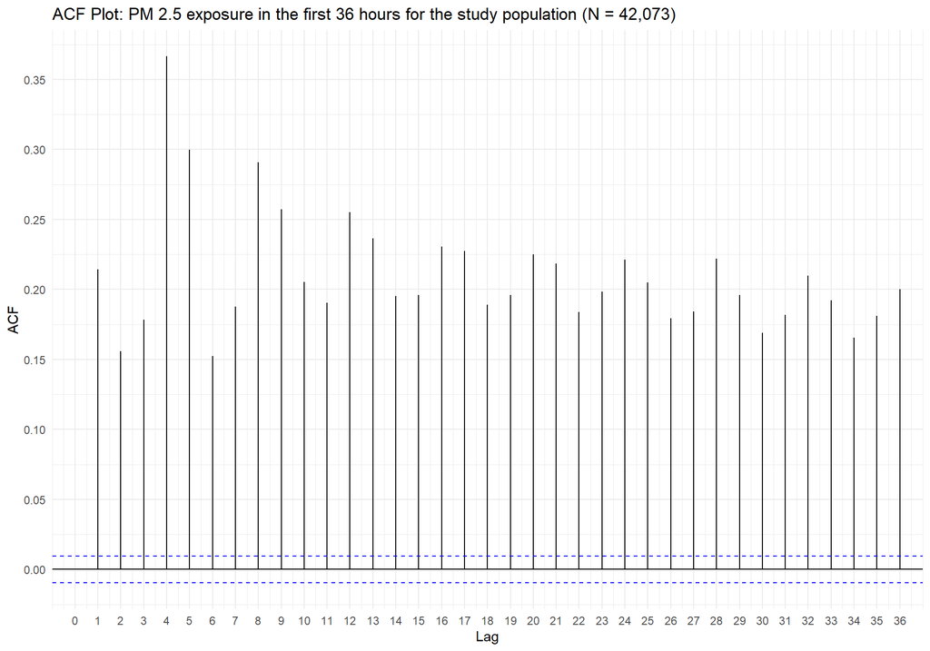

```r
# acf for total study population
acf_BLUME_36h <- ggAcf(dat_analysis_pan_adj$pm25_median_h_Z, lag.max = 36) +
  scale_x_continuous(breaks = seq(0, 36, by = 1),limits = c(0, 36), expand = c(0,1)) +
  scale_y_continuous(breaks = seq(0, 1, by = 0.05)) +
  labs(title = "ACF Plot: PM 2.5 exposure in the first 36 hours for the study population (N = 42,073)") +
  theme_minimal()
print(acf_BLUME_36h)
```

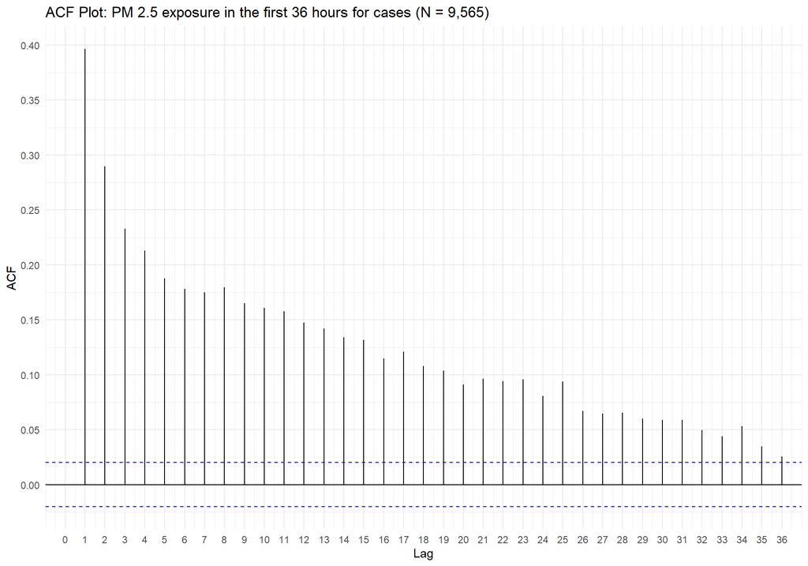

```r
# acf for cases
acf_BLUME_36h_cases_df <- dat_analysis_pan_adj %>%
  filter(stroke == "1")

acf_BLUME_36h_cases <- ggAcf(acf_BLUME_36h_cases_df$pm25_median_h_Z, lag.max = 36) +
  scale_x_continuous(breaks = seq(0, 36, by = 1),limits = c(0, 36), expand = c(0,1)) +
  scale_y_continuous(breaks = seq(0, 1, by = 0.05)) +
  labs(title = "ACF Plot: PM 2.5 exposure in the first 36 hours for cases (N = 9,565)") +
  theme_minimal()
print(acf_BLUME_36h_cases)
```

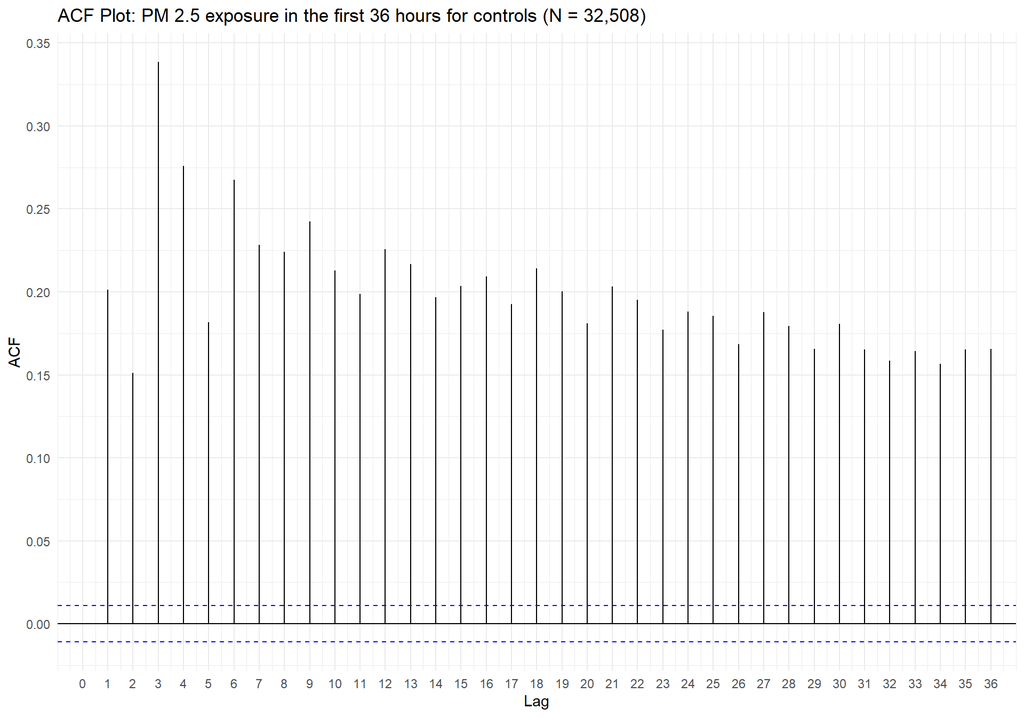

```r
# acf for controls
acf_BLUME_36h_controls_df <- dat_analysis_pan_adj %>%
  filter(stroke == "0")

acf_BLUME_36h_controls <- ggAcf(acf_BLUME_36h_controls_df$pm25_median_h_Z, lag.max = 36) +
  scale_x_continuous(breaks = seq(0, 36, by = 1),limits = c(0, 36), expand = c(0,1)) +
  scale_y_continuous(breaks = seq(0, 1, by = 0.05)) +
  labs(title = "ACF Plot: PM 2.5 exposure in the first 36 hours for controls (N = 32,508)") +
  theme_minimal()
print(acf_BLUME_36h_controls)
```

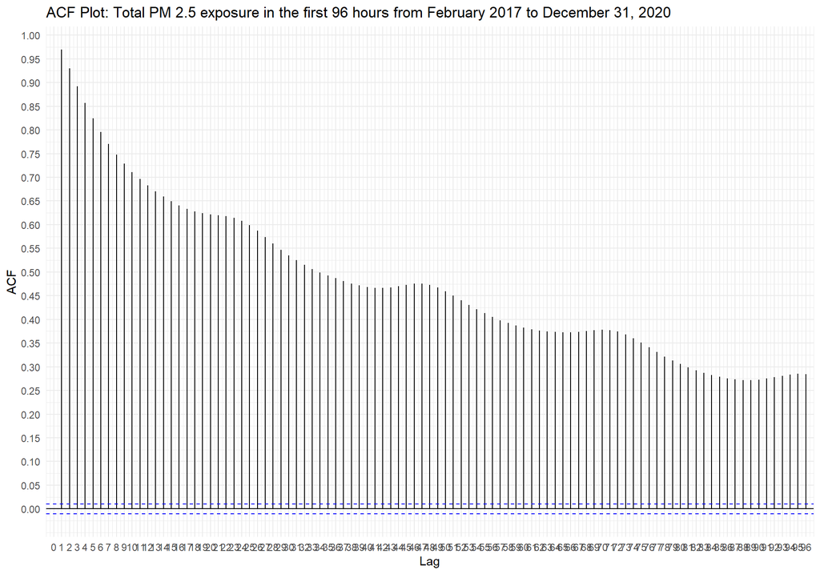

```r
#### 96 & 168 hours

acf_BLUME_96h_total <- ggAcf(exposure_pandemic$pm25_median_h_Z, lag.max = 96) +
  scale_x_continuous(breaks = seq(0, 96, by = 1),limits = c(0, 96), expand = c(0,1)) +
  scale_y_continuous(breaks = seq(0, 1, by = 0.05)) +
  labs(title = "ACF Plot: Total PM 2.5 exposure in the first 96 hours from February 2017 to December 31, 2020") +
  theme_minimal()
# result: data shows very strong positive correlation (> 0.5-1.0) and a decreasing wave in the first 96 hours.
print(acf_BLUME_96h_total)
```

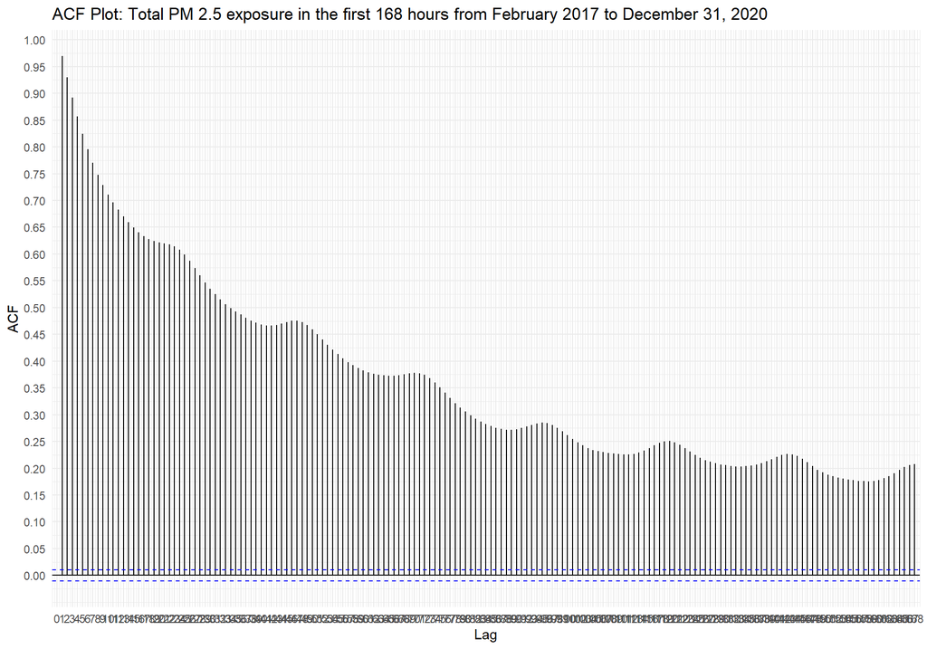

```r
acf_BLUME_168h_total <- ggAcf(exposure_pandemic$pm25_median_h_Z, lag.max = 168) +
  scale_x_continuous(breaks = seq(0, 168, by = 1),limits = c(0, 168), expand = c(0,1)) +
  scale_y_continuous(breaks = seq(0, 1, by = 0.05)) +
  labs(title = "ACF Plot: Total PM 2.5 exposure in the first 168 hours from February 2017 to December 31, 2020") +
  theme_minimal()
# result: data shows very strong positive correlation (> 0.5-1.0) and a decreasing wave in the first 168 hours.
print(acf_BLUME_168h_total)
```

## Adjustment data: DWD network

### German Weather Service stations

- Standardized **hourly data on relative humidity (%), air temperature (°C), and atmospheric pressure (hPa)** measured at a height of two meters were acquired from the **Climate Data Center of the German Weather Service** ( https://cdc.dwd.de/portal/), which maintains five monitoring stations in Berlin.
- Only the **three stations recording all three covariates simultaneously were included in our analysis**. Hourly values for each parameter were determined by calculating the spatial median value of the three stations.
- **Correlation for the respective parameters among all stations** were **very strong** (r>0.99 for air temperature, air pressure & relative humidity).
- **Map description**: The 3 background BLUME stations are represented by the green points. The 3 red points represent the monitoring stations of the German Weather Service.

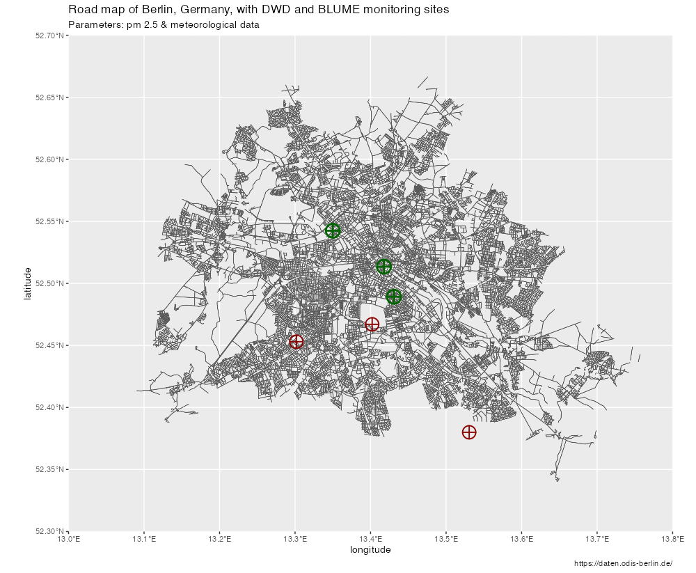

### Meteorological values

- The hourly and daily values for the respective parameters were determined by **calculating the spatial median value based of the three stations (n=3; 400, 403, 427)**.
- **Summary statistics table** showed annual values for all parameters for the time from **February 1, 2017, to December 31,2020**.

```r
summary_DWD_miss <- list(
  "Air Pressure [hPa]" = list(
    "Available (%)" = ~ n_perc0(!is.na(dat_analysis_pan_adj$hour_med_AP)),
    "Missing (%)" = ~ n_perc0(is.na(dat_analysis_pan_adj$hour_med_AP))),
   "Relative Humidity [%]" = list(
    "Available (%)" = ~ n_perc0(!is.na(dat_analysis_pan_adj$hour_med_RH)),
    "Missing (%)" = ~ n_perc0(is.na(dat_analysis_pan_adj$hour_med_RH))),
   "Temperature [°C]" = list(
    "Available (%)" = ~ n_perc0(!is.na(dat_analysis_pan_adj$hour_med_TM)),
    "Missing (%)" = ~ n_perc0(is.na(dat_analysis_pan_adj$hour_med_TM))))
tblq_DWD_miss <- summary_table(dat_analysis_pan_adj, summary_DWD_miss)
print(tblq_DWD_miss)
```

|  | dat_analysis_pan_adj (N = 42,073) |
| --- | --- |
| **Air Pressure [hPa]** |  |
| Available (%) | 42,073 (100) |
| Missing (%) | 0 (0) |
| **Relative Humidity [%]** |  |
| Available (%) | 42,073 (100) |
| Missing (%) | 0 (0) |
| **Temperature [°C]** |  |
| Available (%) | 42,073 (100) |
| Missing (%) | 0 (0) |

```r
##### table1: exposure and adjustment variables DWD UPDATE
DWD_dat_pandemic$year <- as.numeric(format(DWD_dat_pandemic$case_date, "%Y"))
exposure_pandemic$year <- as.numeric(format(exposure_pandemic$case_time, "%Y"))

exposure_pandemic <- exposure_pandemic %>%
  select(case_time, pm25_median_h)

DWD_dat_pandemic <- DWD_dat_pandemic %>%
  filter(case_date > "2017-02-01 01:00:00") %>%
  filter((case_date < "2021-01-01 01:00:00"))
DWD_dat_pandemic <- DWD_dat_pandemic %>%
  rename(case_time = case_date)


all_dat <- left_join(DWD_dat_pandemic, exposure_pandemic, by = "case_time")

#complete_dat
dat_compl <- all_dat

summary_tbl_complete_dat <- list(
  "PM2.5 [m3/µg]" = list(
    "Min" = ~ min(dat_compl$pm25_median_h, na.rm=TRUE),
    "Median (IQR)" = ~ median_iqr(dat_compl$pm25_median_h, na_rm=TRUE),
    "Mean (SD)" = ~ mean_sd(dat_compl$pm25_median_h, denote_sd = "paren",, na_rm=TRUE),
    "Max" = ~ max(dat_compl$pm25_median_h, na.rm=TRUE),
    "Missing (%)" = ~ n_perc0(is.na(dat_compl$pm25_median_h))
  ),
  "Air Pressure [hPa]" = list(
    "Min" = ~ min(dat_compl$hour_med_AP),
    "Median (IQR)" = ~ median_iqr(dat_compl$hour_med_AP, na_rm=TRUE),
    "Mean (SD)" = ~ mean_sd(dat_compl$hour_med_AP, denote_sd = "paren", na_rm=TRUE),
    "Max" = ~ max(dat_compl$hour_med_AP),
    "Missing (%)" = ~ n_perc0(is.na(dat_compl$hour_med_AP))
  ),
  "Relative Humidity [%]" = list(
    "Min" = ~ min(dat_compl$hour_med_RH),
    "Median (IQR)" = ~ median_iqr(dat_compl$hour_med_RH, na_rm=TRUE),
    "Mean (SD)" = ~ mean_sd(dat_compl$hour_med_RH, denote_sd = "paren", na_rm=TRUE),
    "Max" = ~ max(dat_compl$hour_med_RH),
    "Missing (%)" = ~ n_perc0(is.na(dat_compl$hour_med_RH))
  ),
  "Temperature [°C]" = list(
    "Min" = ~ min(dat_compl$hour_med_TM),
    "Median (IQR)" = ~ median_iqr(dat_compl$hour_med_TM, na_rm=TRUE),
    "Mean (SD)" = ~ mean_sd(dat_compl$hour_med_TM, denote_sd = "paren", na_rm=TRUE),
    "Max" = ~ max(dat_compl$hour_med_TM),
    "Missing (%)" = ~ n_perc0(is.na(dat_compl$hour_med_TM))
  )
)
tbl_compl_dat <- summary_table(dat_compl, summary_tbl_complete_dat)


#2017
dat_2017 <- all_dat %>%
  filter(year==2017)

summary_tbl_2017 <- list(
  "PM2.5 [m3/µg]" = list(
    "Min" = ~ min(dat_2017$pm25_median_h),
    "Median (IQR)" = ~ median_iqr(dat_2017$pm25_median_h),
    "Mean (SD)" = ~ mean_sd(dat_2017$pm25_median_h, denote_sd = "paren"),
    "Max" = ~ max(dat_2017$pm25_median_h),
    "Missing (%)" = ~ n_perc0(is.na(dat_2017$pm25_median_h))
  ),
  "Air Pressure [hPa]" = list(
    "Min" = ~ min(dat_2017$hour_med_AP),
    "Median (IQR)" = ~ median_iqr(dat_2017$hour_med_AP),
    "Mean (SD)" = ~ mean_sd(dat_2017$hour_med_AP, denote_sd = "paren"),
    "Max" = ~ max(dat_2017$hour_med_AP),
    "Missing (%)" = ~ n_perc0(is.na(dat_2017$hour_med_AP))
  ),
  "Relative Humidity [%]" = list(
    "Min" = ~ min(dat_2017$hour_med_RH),
    "Median (IQR)" = ~ median_iqr(dat_2017$hour_med_RH),
    "Mean (SD)" = ~ mean_sd(dat_2017$hour_med_RH, denote_sd = "paren"),
    "Max" = ~ max(dat_2017$hour_med_RH),
    "Missing (%)" = ~ n_perc0(is.na(dat_2017$hour_med_RH))
  ),
  "Temperature [°C]" = list(
    "Min" = ~ min(dat_2017$hour_med_TM),
    "Median (IQR)" = ~ median_iqr(dat_2017$hour_med_TM),
    "Mean (SD)" = ~ mean_sd(dat_2017$hour_med_TM, denote_sd = "paren"),
    "Max" = ~ max(dat_2017$hour_med_TM),
    "Missing (%)" = ~ n_perc0(is.na(dat_2017$hour_med_TM))
  )
)
tbl_2017 <- summary_table(dat_2017, summary_tbl_2017)



#2018
dat_2018 <- all_dat %>%
  filter(year==2018)

summary_tbl_2018 <- list(
  "PM2.5 [m3/µg]" = list(
    "Min" = ~ min(dat_2018$pm25_median_h),
    "Median (IQR)" = ~ median_iqr(dat_2018$pm25_median_h),
    "Mean (SD)" = ~ mean_sd(dat_2018$pm25_median_h, denote_sd = "paren"),
    "Max" = ~ max(dat_2018$pm25_median_h),
    "Missing (%)" = ~ n_perc0(is.na(dat_2018$pm25_median_h))
  ),
  "Air Pressure [hPa]" = list(
    "Min" = ~ min(dat_2018$hour_med_AP),
    "Median (IQR)" = ~ median_iqr(dat_2018$hour_med_AP),
    "Mean (SD)" = ~ mean_sd(dat_2018$hour_med_AP, denote_sd = "paren"),
    "Max" = ~ max(dat_2018$hour_med_AP),
    "Missing (%)" = ~ n_perc0(is.na(dat_2018$hour_med_AP))
  ),
  "Relative Humidity [%]" = list(
    "Min" = ~ min(dat_2018$hour_med_RH),
    "Median (IQR)" = ~ median_iqr(dat_2018$hour_med_RH),
    "Mean (SD)" = ~ mean_sd(dat_2018$hour_med_RH, denote_sd = "paren"),
    "Max" = ~ max(dat_2018$hour_med_RH),
    "Missing (%)" = ~ n_perc0(is.na(dat_2018$hour_med_RH))
  ),
  "Temperature [°C]" = list(
    "Min" = ~ min(dat_2018$hour_med_TM),
    "Median (IQR)" = ~ median_iqr(dat_2018$hour_med_TM),
    "Mean (SD)" = ~ mean_sd(dat_2018$hour_med_TM, denote_sd = "paren"),
    "Max" = ~ max(dat_2018$hour_med_TM),
    "Missing (%)" = ~ n_perc0(is.na(dat_2018$hour_med_TM))
  )
)
tbl_2018 <- summary_table(dat_2018, summary_tbl_2018)


#2019
dat_2019 <- all_dat %>%
  filter(year==2019)

summary_tbl_2019 <- list(
  "PM2.5 [m3/µg]" = list(
    "Min" = ~ min(dat_2019$pm25_median_h),
    "Median (IQR)" = ~ median_iqr(dat_2019$pm25_median_h),
    "Mean (SD)" = ~ mean_sd(dat_2019$pm25_median_h, denote_sd = "paren"),
    "Max" = ~ max(dat_2019$pm25_median_h),
    "Missing (%)" = ~ n_perc0(is.na(dat_2019$pm25_median_h))
  ),
  "Air Pressure [hPa]" = list(
    "Min" = ~ min(dat_2019$hour_med_AP),
    "Median (IQR)" = ~ median_iqr(dat_2019$hour_med_AP),
    "Mean (SD)" = ~ mean_sd(dat_2019$hour_med_AP, denote_sd = "paren"),
    "Max" = ~ max(dat_2019$hour_med_AP),
    "Missing (%)" = ~ n_perc0(is.na(dat_2019$hour_med_AP))
  ),
  "Relative Humidity [%]" = list(
    "Min" = ~ min(dat_2019$hour_med_RH),
    "Median (IQR)" = ~ median_iqr(dat_2019$hour_med_RH),
    "Mean (SD)" = ~ mean_sd(dat_2019$hour_med_RH, denote_sd = "paren"),
    "Max" = ~ max(dat_2019$hour_med_RH),
    "Missing (%)" = ~ n_perc0(is.na(dat_2019$hour_med_RH))
  ),
  "Temperature [°C]" = list(
    "Min" = ~ min(dat_2019$hour_med_TM),
    "Median (IQR)" = ~ median_iqr(dat_2019$hour_med_TM),
    "Mean (SD)" = ~ mean_sd(dat_2019$hour_med_TM, denote_sd = "paren"),
    "Max" = ~ max(dat_2019$hour_med_TM),
    "Missing (%)" = ~ n_perc0(is.na(dat_2019$hour_med_TM))
  )
)
tbl_2019 <- summary_table(dat_2019, summary_tbl_2019)


#2020
dat_2020 <- all_dat %>%
  filter(year==2020)

summary_tbl_2020 <- list(
  "PM2.5 [m3/µg]" = list(
    "Min" = ~ min(dat_2020$pm25_median_h),
    "Median (IQR)" = ~ median_iqr(dat_2020$pm25_median_h),
    "Mean (SD)" = ~ mean_sd(dat_2020$pm25_median_h, denote_sd = "paren"),
    "Max" = ~ max(dat_2020$pm25_median_h),
    "Missing (%)" = ~ n_perc0(is.na(dat_2020$pm25_median_h))
  ),
  "Air Pressure [hPa]" = list(
    "Min" = ~ min(dat_2020$hour_med_AP),
    "Median (IQR)" = ~ median_iqr(dat_2020$hour_med_AP),
    "Mean (SD)" = ~ mean_sd(dat_2020$hour_med_AP, denote_sd = "paren"),
    "Max" = ~ max(dat_2020$hour_med_AP),
    "Missing (%)" = ~ n_perc0(is.na(dat_2020$hour_med_AP))
  ),
  "Relative Humidity [%]" = list(
    "Min" = ~ min(dat_2020$hour_med_RH),
    "Median (IQR)" = ~ median_iqr(dat_2020$hour_med_RH),
    "Mean (SD)" = ~ mean_sd(dat_2020$hour_med_RH, denote_sd = "paren"),
    "Max" = ~ max(dat_2020$hour_med_RH),
    "Missing (%)" = ~ n_perc0(is.na(dat_2020$hour_med_RH))
  ),
  "Temperature [°C]" = list(
    "Min" = ~ min(dat_2020$hour_med_TM),
    "Median (IQR)" = ~ median_iqr(dat_2020$hour_med_TM),
    "Mean (SD)" = ~ mean_sd(dat_2020$hour_med_TM, denote_sd = "paren"),
    "Max" = ~ max(dat_2020$hour_med_TM),
    "Missing (%)" = ~ n_perc0(is.na(dat_2020$hour_med_TM))
  )
)
tbl_2020 <- summary_table(dat_2020, summary_tbl_2020)
```

```r
# merge tables
tbl_compl <- cbind(tbl_compl_dat, tbl_2017, tbl_2018, tbl_2019, tbl_2020)
colnames(tbl_compl) <- c(" ", "Total","2017", "2018","2019","2020")
print(tbl_compl)
```

|  | dat_compl (N = 34,319) | dat_2017 (N = 8,015) | dat_2018 (N = 8,760) | dat_2019 (N = 8,760) | dat_2020 (N = 8,784) |
| --- | --- | --- | --- | --- | --- |
| **PM2.5 [m3/µg]** |  |  |  |  |  |
| Min | 0.97 | 1.4 | 1.29 | 0.97 | 1.62 |
| Median (IQR) | 10.49 (6.74, 17.56) | 10.95 (7.25, 17.79) | 12.56 (7.45, 21.89) | 10.10 (6.62, 17.05) | 8.95 (5.97, 14.75) |
| Mean (SD) | 13.79 (10.28) | 14.33 (10.58) | 16.18 (11.75) | 13.39 (10.07) | 11.30 (7.72) |
| Max | 185.13 | 74.29 | 136.99 | 185.13 | 184.22 |
| Missing (%) | 0 (0) | 0 (0) | 0 (0) | 0 (0) | 0 (0) |
| **Air Pressure [hPa]** |  |  |  |  |  |
| Min | 974.8 | 974.8 | 975.3 | 976.8 | 976.6 |
| Median (IQR) | 1,009.90 (1,004.00, 1,015.50) | 1,009.90 (1,004.30, 1,014.90) | 1,010.50 (1,005.40, 1,015.40) | 1,008.40 (1,002.30, 1,015.40) | 1,010.60 (1,004.20, 1,016.10) |
| Mean (SD) | 1,009.39 (9.26) | 1,009.18 (8.77) | 1,010.04 (8.42) | 1,008.50 (10.08) | 1,009.81 (9.58) |
| Max | 1040.7 | 1032.7 | 1032.6 | 1039.8 | 1040.7 |
| Missing (%) | 0 (0) | 0 (0) | 0 (0) | 0 (0) | 0 (0) |
| **Relative Humidity [%]** |  |  |  |  |  |
| Min | 11 | 14 | 19 | 11 | 21 |
| Median (IQR) | 76.00 (59.00, 89.00) | 80.00 (65.00, 90.00) | 74.00 (56.00, 87.00) | 76.00 (58.00, 89.00) | 76.00 (58.00, 88.00) |
| Mean (SD) | 72.46 (18.92) | 75.82 (16.61) | 70.32 (19.47) | 72.18 (19.32) | 71.79 (19.53) |
| Max | 100 | 100 | 100 | 100 | 100 |
| Missing (%) | 0 (0) | 0 (0) | 0 (0) | 0 (0) | 0 (0) |
| **Temperature [°C]** |  |  |  |  |  |
| Min | -12.8 | -8.3 | -12.8 | -6.7 | -4.4 |
| Median (IQR) | 10.80 (5.20, 17.30) | 11.10 (5.90, 16.70) | 11.10 (3.80, 18.70) | 10.50 (5.30, 17.30) | 10.50 (5.60, 16.80) |
| Mean (SD) | 11.45 (7.99) | 11.39 (7.13) | 11.45 (9.20) | 11.54 (8.03) | 11.43 (7.39) |
| Max | 37.9 | 31.7 | 36.9 | 37.9 | 35.4 |
| Missing (%) | 0 (0) | 0 (0) | 0 (0) | 0 (0) | 0 (0) |

```r
#tbl_compl_df <- as.data.frame(tbl_compl)
#write.csv2(tbl_compl_df, file = "S:\\Fakultaet\\MFZ\\MFZ-CSB\\REG-B-SPATIAL\\Jakob\\PM25_stroke\\24102023_tab_DWD_BLUME.csv")
```

### Distribution of the meteorological data

- All parameters showed a **non-linear distribution or deviations from normal distribution**.
- **Short summary of visual inspection**:
1. **Air pressure (AP)**: slightly left-skewed; rather non-linear distribution / deviation from normal distribution
2. **Relative humidity (RH)**: clearly left-skewed; rather non-linear distribution, s-shape in Q-Q plot
3. **Temperature (TM)**: M-shape in histogram (greater peak at approximately 10°C, second peak at approximately 20°C), both margins rather symmetrical; rather non-linear distribution, flat s-shape in Q-Q plot
- **Spearman and Pearson correlation analyses among meteorological parameters and PM2.5 values** showed **mainly weak correlations**.
- **PM2.5 values had the strongest correlation with**
1. **relative humidity** (RH; weak positive correlation, r=0.32),
2. **temperature** (TM; weak negative correlation, r=-0.30) and
3. differed when stratified by weekday, daytime or public holiday.

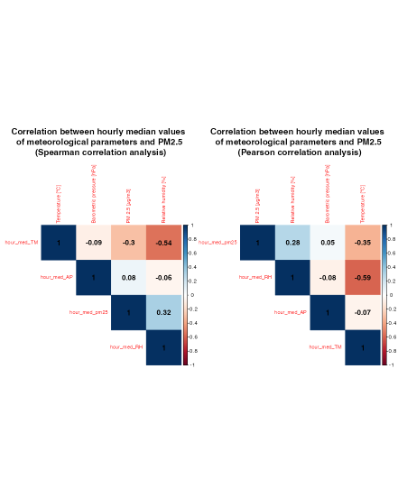

- Histogram and Q-Q-plot for air pressure

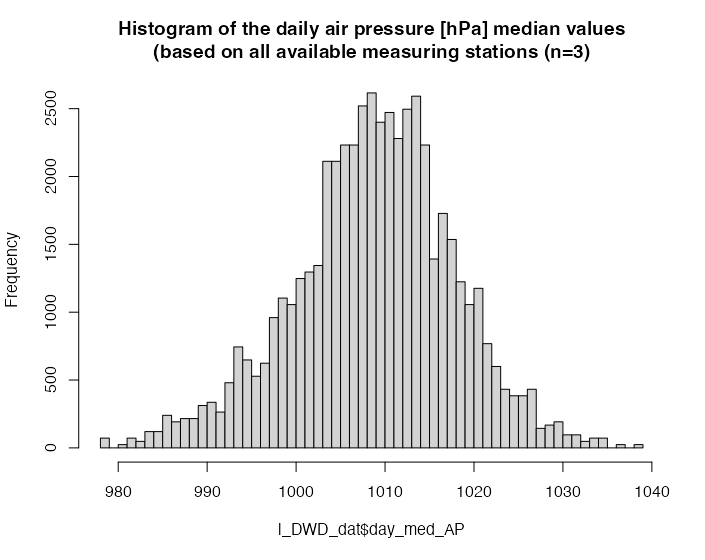

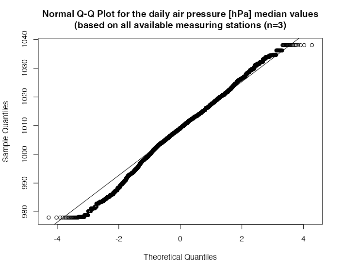

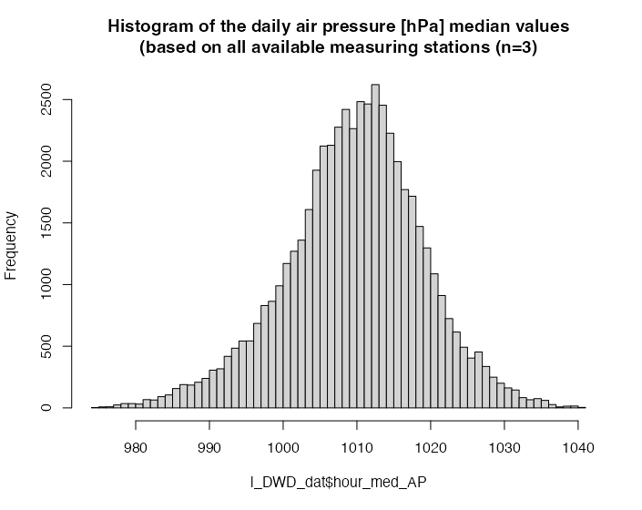

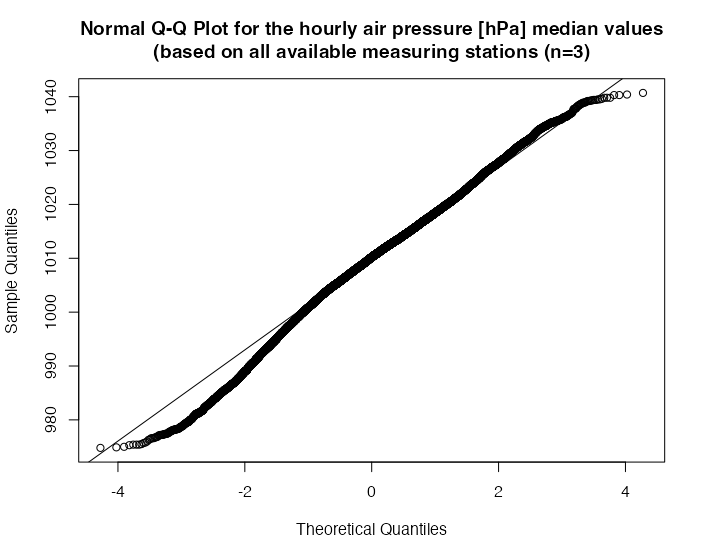

- Histogram and Q-Q-plot for temperature

[figure not shown]